# Road Condition Prediction Using Machine Learning

**AAI - 530 : Final Team Project**  
**Submitted to:** Prof. Ana Marbut  
**University of San Diego**

## Introduction

This project focuses on **Road Condition Prediction Using Machine Learning**, leveraging different deep learning models to classify road surfaces based on vehicle sensor data. The primary goal is to enhance road safety by accurately predicting surface conditions such as **asphalt, cobblestone, and dirt**.

We experimented with **GRU (Gated Recurrent Units)**, **LSTM (Long Short-Term Memory)**, and **Random Forest**, analyzing their performance in predicting road types based on historical vehicle data. Our work also includes **data cleaning, exploratory data analysis (EDA), and model evaluation** to ensure high accuracy.

### **Project Objectives**

- Predict road surface conditions using **sensor and vehicle telemetry data**.
- Compare the performance of **GRU, LSTM, and Random Forest** models.
- Identify key patterns in road conditions using machine learning techniques.
- Visualize results and model performance using **Tableau dashboards**.
- Explore future improvements, such as **vehicle speed behavior analysis**.

### **Repository & Resources**

- 📂 **GitHub Repository**: Final-Team-Project-ML-IoT-Application
- 📊 **Tableau Dashboard**: *([Tableau Dashboard](https://public.tableau.com/views/Final-Team-Project-ML-IoT-Application/Dashboard1?:language=en-US&:sid=&:redirect=auth&:display_count=n&:origin=viz_share_link))*
- 🗄️ **Source: Kaggle Dataset**: *([Dataset](https://www.kaggle.com/code/jefmenegazzo/pvs-data-exploration))*
- 📝 **Contributors**:
  - Issa Ennab
  - Manikanta Katuri
  - Ajmal Jalal

### **Project Overview**

[figure not shown]

## IoT System Design

### Edge-Based Vehicular IoT System for Real-Time Safety & Data Processing

This IoT system is designed primarily for vehicular edge computing, enabling real-time data processing and enhanced road safety. However, future enhancements introduce a hybrid approach, integrating both edge and cloud computing to optimize data collection, analysis, and transmission of critical vehicle and environmental data.

### System Components

#### 1️⃣ Edge Computing & Sensors

The system collects real-time data from multiple onboard sensors, each playing a vital role:

- **GPS Sensor (Xiaomi Mi 8, 1 Hz)** → Captures speed, latitude, longitude, and elevation.
- **Accelerometer (MPU-9250, 100 Hz)** → Measures vehicle acceleration.
- **Gyroscope (MPU-9250, 100 Hz)** → Tracks rotational movements.
- **Magnetometer (MPU-9250, 100 Hz)** → Detects ambient geomagnetic fields.
- **Temperature Sensor (MPU-9250, 100 Hz)** → Monitors temperature fluctuations.
- **HD Camera (HP Webcam HD-4110, 30 Hz)** → Captures video footage.

#### 2️⃣ Data Processing & Storage

- **SD Card** → Stores raw sensor data for offline analysis.
- **Edge Computing Unit** → Processes data locally before transmission, reducing cloud dependency.

#### 3️⃣ Communication & Messaging

- **GPS Module** → Communicates with GPS satellites for precise location tracking.
- **LTE Module** → Sends data via HTTPS to the cloud. *Suggested Future Enhancements*
- **MQTT Messaging** → Enables low-latency communication for alerts and real-time updates. *Suggested Future Enhancements*

#### 4️⃣ Cloud Computing & Integration *Suggested Future Enhancements*

- **AWS IoT Core / Azure IoT Hub / Google Cloud IoT** → Centralized data aggregation, analytics, and remote monitoring.
- **Road & Safety City Systems** → Processes hazard alerts for traffic management and infrastructure planning.

### Existing System *Black (Solid Lines):*

The current implementation supports edge-based data collection and storage, with GPS tracking and LTE-based cloud communication.

### Future Enhancements *Orange (Dashed Lines):*

- **Hazard Detection & Alerting** → Sensors detect road hazards (e.g., icy roads, sharp braking, high vibrations) and trigger alerts.
- **Vehicle-to-Vehicle (V2V) Communication** → Uses MQTT to broadcast alerts to nearby vehicles, enhancing proactive safety.
- **Enhanced Cloud Integration** → GPS data will be re-routed to cloud platforms, enabling long-term tracking & analytics.

### Why This Matters

This edge-based IoT system allows vehicles to process data locally while maintaining critical cloud connectivity for remote monitoring & future improvements. With V2V communication and hazard detection, this system has the potential to revolutionize real-time traffic safety and road condition awareness.

### **IoT System Diagram**

[figure not shown]

## Data Exploration & Cleaning

Before building our machine learning models, we first need to explore and clean our dataset. This involves:

- Understanding the structure of the dataset.
- Identifying missing or inconsistent data.
- Performing feature selection and engineering.
- Preparing the data for model training.

We will walk through the key steps of **data cleaning**, explaining the transformations and justifications behind them. The dataset contains sensor readings from multiple sources, which will be preprocessed to ensure consistency and accuracy.

Next, we will begin our **Exploratory Data Analysis (EDA)** to visualize key trends and distributions before proceeding to model training.

## 📥 Loading the Dataset

The dataset comprises **nine experiments**, each representing a **vehicle-driven route on mixed road types** (asphalt, cobblestone, dirt). The experiments were conducted using **three different vehicles** across **three scenarios**:

| Experiment | Vehicle | Scenario |
| --- | --- | --- |
| PVS 1-3 | Volkswagen Saveiro | Scenario 1, 2, 3 |
| PVS 4-6 | Fiat Bravo | Scenario 1, 2, 3 |
| PVS 7-9 | Fiat Palio | Scenario 1, 2, 3 |

Each experiment contains sensor data (accelerometers, gyroscopes, magnetometers), GPS readings, and labeled road conditions.  
To **facilitate future analysis and comparisons**, we **merged all experiments into a single master dataset**. During this process, we **appended three additional fields**:

- `experiment_id`: Identifies the source experiment (e.g., PVS 1, PVS 2…)
- `vehicle`: Identifies the vehicle used (e.g., Volkswagen Saveiro)
- `scenario`: Denotes the scenario number (e.g., Scenario 1)

This allows us to **filter by vehicle, scenario, or experiment** later for **comparative analysis** or **model evaluation**.

```python
import pandas as pd
import numpy as np
import seaborn as sns
import os
import matplotlib.pyplot as plt
from IPython.display import display
```

```python
# Base directory containing the PVS folders
base_dir = 'dataset/'

# Vehicle and scenario mapping based on the provided table
experiment_metadata = {
    'PVS 1': {'vehicle': 'Volkswagen Saveiro', 'scenario': 'Scenario 1'},
    'PVS 2': {'vehicle': 'Volkswagen Saveiro', 'scenario': 'Scenario 2'},
    'PVS 3': {'vehicle': 'Volkswagen Saveiro', 'scenario': 'Scenario 3'},
    'PVS 4': {'vehicle': 'Fiat Bravo', 'scenario': 'Scenario 1'},
    'PVS 5': {'vehicle': 'Fiat Bravo', 'scenario': 'Scenario 2'},
    'PVS 6': {'vehicle': 'Fiat Bravo', 'scenario': 'Scenario 3'},
    'PVS 7': {'vehicle': 'Fiat Palio', 'scenario': 'Scenario 1'},
    'PVS 8': {'vehicle': 'Fiat Palio', 'scenario': 'Scenario 2'},
    'PVS 9': {'vehicle': 'Fiat Palio', 'scenario': 'Scenario 3'},
}

# Empty list to collect dataframes
all_dataframes = []
```

```python
# mpu_left = pd.read_csv('dataset/PVS 1/dataset_mpu_left.csv')

# Iterate over each PVS folder
for pvs_id, meta in experiment_metadata.items():
    folder_path = os.path.join(base_dir, pvs_id)

    # Load the relevant CSVs
    mpu_left = pd.read_csv(os.path.join(folder_path, 'dataset_mpu_left.csv'))
    mpu_right = pd.read_csv(os.path.join(folder_path, 'dataset_mpu_right.csv'))
    gps = pd.read_csv(os.path.join(folder_path, 'dataset_gps.csv'))
    labels = pd.read_csv(os.path.join(folder_path, 'dataset_labels.csv'))

    # Merge MPU Left and MPU Right on timestamp
    mpu_combined = pd.merge(mpu_left, mpu_right, on='timestamp', suffixes=('_left', '_right'))

    # Merge GPS with combined MPU
    merged_data = pd.merge(mpu_combined, gps, on='timestamp', how='left')

    # Merge with Labels
    merged_data = pd.merge(merged_data, labels, left_index=True, right_index=True, how='left')

    # Add experiment-level metadata
    merged_data['experiment_id'] = pvs_id
    merged_data['vehicle'] = meta['vehicle']
    merged_data['scenario'] = meta['scenario']

    # Collect dataframe
    all_dataframes.append(merged_data)

# Concatenate all experiment data into a master dataframe
master_df = pd.concat(all_dataframes, ignore_index=True)
```

## 🧾 Initial Dataset Summary

We analyzed the combined dataset, resulting in:

- **1,080,905 rows**
- **91 features**

The **merged dataset** is **saved as `master_dataset.csv`** for future use.

```python
# Save as CSV for future use
master_df.to_csv('dataset/master_dataset.csv', index=False)

# Display a summary
print(f"Final Dataset Shape: {master_df.shape}")
print(master_df.head())
```

```
Final Dataset Shape: (1080905, 91)
      timestamp  acc_x_dashboard_left  acc_y_dashboard_left  \
0  1.577219e+09              0.365116              0.167893
1  1.577219e+09              0.392649              0.176273
2  1.577219e+09              0.409408              0.181062
3  1.577219e+09              0.371101              0.164302
4  1.577219e+09              0.390255              0.159514

   acc_z_dashboard_left  acc_x_above_suspension_left  \
0              9.793961                     0.327626
1              9.771216                     0.381496
2              9.732909                     0.283333
3              9.749668                     0.314458
4              9.869378                     0.344385

```

[output cut: 36 more lines]

## 🧾 Dataset Summary

To better understand the structure and quality of the dataset used in this project, we generated a summary table highlighting key characteristics of each feature. This summary provides insights into the data types, non-null counts, and a quick overview of missing values, aiding in the data cleaning and preparation process.

```python
# Prepare summary table
summary_data = [{
    'Dataset Name': 'master_dataset',
    'Number of Rows': master_df.shape[0],
    'Number of Columns': master_df.shape[1],
    'Duplicates': master_df.duplicated().sum(),
    'Missing Values': master_df.isnull().sum().sum(),
    'Sample Columns': ', '.join(master_df.columns[:5]) + ('...' if len(master_df.columns) > 5 else '')
}]

# Convert to DataFrame
summary_df = pd.DataFrame(summary_data)

# Display the summary as a clean DataFrame
display(summary_df)
```

|  | Dataset Name | Number of Rows | Number of Columns | Duplicates | Missing Values | Sample Columns |
| --- | --- | --- | --- | --- | --- | --- |
| 0 | master_dataset | 1080905 | 91 | 0 | 20443399 | timestamp, acc_x_dashboard_left, acc_y_dashboa... |

```python
summary_df.to_csv('dataset/summary_master_dataset.csv', index=False)
# print(summary_df.to_markdown())
```

## Visualize Missing Values

We plotted the missing values, revealing that certain columns (latitude, longitude, accuracy, and GPS-related) had over 99% missing values. This led us to evaluate their relevance.

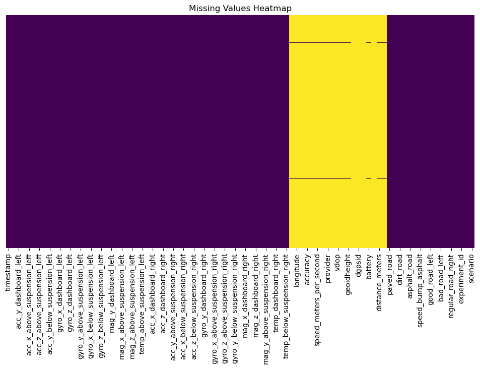

```python
plt.figure(figsize=(12, 6))
sns.heatmap(master_df.isnull(), cbar=False, yticklabels=False, cmap='viridis')
plt.title('Missing Values Heatmap')
plt.show()
```

```python
# Count non-null values for latitude, longitude, and accuracy
non_null_counts = master_df[['latitude', 'longitude', 'accuracy']].notnull().sum()
print(non_null_counts)
```

```
latitude     6254
longitude    6254
accuracy     6254
dtype: int64
```

## 🧹 Data Cleaning Process

As part of the data preparation process, we carefully examined the dataset for **missing values, duplicates, and irrelevant features**. Our approach was guided by both **statistical analysis** and **domain understanding**. Key decisions and steps are outlined below:

### 1. Handling Missing Values

Upon visualizing the missing values using a heatmap, we observed that several GPS-related columns (e.g., `latitude`, `longitude`, `accuracy`) contained **sparse data** (less than 1% non-null records). Such sparse features hold **little predictive value** and could introduce noise into the models.

- **Non-null Counts:**
  - `latitude`: 6254 (0.58%)
  - `longitude`: 6254 (0.58%)
  - `accuracy`: 6254 (0.58%)

These columns, along with other irrelevant fields, were **dropped** from the dataset.

### 2. Columns Removed:

| Column Name | Reason for Removal |
| --- | --- |
| `latitude` | Sparse data (0.58%), irrelevant for vibration-based prediction |
| `longitude` | Same as above |
| `accuracy` | Sparse data, related to GPS quality, not road condition |
| `bearing` | Mostly null, GPS directional data, not required |
| `geoidheight` | Elevation reference, not predictive in our context |
| `ageofdgpsdata` | Sparse, not relevant |
| `dgpsid` | Sparse, not relevant |
| `provider` | Text data, carrier info, irrelevant |
| `annotation` | Mostly null, likely for labeling, not predictive |
| `battery` | Battery level, not influencing road vibrations |

### 3. Final Cleaned Dataset:

After removing the above columns, our **final dataset** consists of **81 features and 1,080,905 records**.

### 📊 Visual Summary

A heatmap of missing values confirmed that the removed columns had **large gaps**, validating our decision to **drop them**.

```python
# Columns to remove based on missing values and irrelevance
cleaned_df = master_df.copy()
columns_to_drop = [
    'latitude', 'longitude', 'accuracy', 'bearing', 'geoidheight',
    'ageofdgpsdata', 'dgpsid', 'provider', 'annotation', 'battery'
]

# Drop the columns from the master dataframe
cleaned_df.drop(columns=columns_to_drop, inplace=True)

# Save the cleaned dataset
cleaned_df.to_csv('dataset/cleaned_master_dataset.csv', index=False)

# Confirm the changes
print(f"Final Dataset Shape After Dropping Columns: {cleaned_df.shape}")
```

```
Final Dataset Shape After Dropping Columns: (1080905, 81)
```

# Exploratory Data Analysis (EDA)

We aim to explore and analyze the dataset by performing initial data cleaning and generating key visualizations to understand the distribution and patterns in the data.

## Basic Descriptive Statistics

Summary statistics are calculated to understand the central tendency and spread of the data. This includes measures such as mean, median, and standard deviation.

```python
# 1. Descriptive Statistics per Vehicle

# Calculate descriptive statistics for each vehicle
# This includes count, mean, std, min, 25%, 50%, 75%, and max for each sensor axis
descriptive_vehicle_stats = master_df.groupby('vehicle')[['acc_x_dashboard_left', 'acc_y_dashboard_left', 'acc_z_dashboard_left']].describe()

# Display the descriptive statistics
display(descriptive_vehicle_stats)

# Save the descriptive statistics to a CSV file
descriptive_vehicle_stats.to_csv('dataset/descriptive_vehicle_stats.csv')
```

| vehicle | acc_x_dashboard_left count | acc_x_dashboard_left mean | acc_x_dashboard_left std | acc_x_dashboard_left min | acc_x_dashboard_left 25% | acc_x_dashboard_left 50% | acc_x_dashboard_left 75% | acc_x_dashboard_left max | acc_y_dashboard_left count | acc_y_dashboard_left mean | acc_y_dashboard_left ... | acc_y_dashboard_left 75% | acc_y_dashboard_left max | acc_z_dashboard_left count | acc_z_dashboard_left mean | acc_z_dashboard_left std | acc_z_dashboard_left min | acc_z_dashboard_left 25% | acc_z_dashboard_left 50% | acc_z_dashboard_left 75% | acc_z_dashboard_left max |
| --- | --- | --- | --- | --- | --- | --- | --- | --- | --- | --- | --- | --- | --- | --- | --- | --- | --- | --- | --- | --- | --- |
| Fiat Bravo | 362648.0 | 0.257525 | 1.306369 | -9.151631 | -0.469503 | 0.226456 | 1.024479 | 7.599555 | 362648.0 | -0.145169 | ... | 0.683282 | 12.183075 | 362648.0 | 9.782362 | 1.289326 | -1.027292 | 9.205526 | 9.796894 | 10.385867 | 19.458144 |
| Fiat Palio | 343721.0 | 0.246039 | 1.314881 | -8.111316 | -0.502543 | 0.225294 | 0.979468 | 8.826195 | 343721.0 | -0.144058 | ... | 0.758124 | 14.567608 | 343721.0 | 9.823909 | 2.214910 | -8.036258 | 8.820064 | 9.825628 | 10.842023 | 34.504815 |
| Volkswagen Saveiro | 374536.0 | 0.229567 | 1.429087 | -10.735600 | -0.495600 | 0.232597 | 0.964863 | 13.957495 | 374536.0 | -0.140564 | ... | 0.660022 | 18.276868 | 374536.0 | 9.788493 | 1.752436 | -9.491693 | 9.029851 | 9.791207 | 10.558549 | 24.665544 |

3 rows × 24 columns

```python
# 2. Pivot Table - Aggregating Sensor Data per Vehicle and Scenario

# Create a pivot table to aggregate sensor data per vehicle and scenario
pivot_vehicle_scenario = master_df.pivot_table(
    values=['acc_x_dashboard_left', 'acc_y_dashboard_left', 'acc_z_dashboard_left'],
    index='vehicle',
    columns='scenario',
    aggfunc='mean'
)

# Display the pivot table
display(pivot_vehicle_scenario)

# Save the pivot table to a CSV file
pivot_vehicle_scenario.to_csv('dataset/pivot_vehicle_scenario.csv')
```

| scenario vehicle | acc_x_dashboard_left Scenario 1 | acc_x_dashboard_left Scenario 2 | acc_x_dashboard_left Scenario 3 | acc_y_dashboard_left Scenario 1 | acc_y_dashboard_left Scenario 2 | acc_y_dashboard_left Scenario 3 | acc_z_dashboard_left Scenario 1 | acc_z_dashboard_left Scenario 2 | acc_z_dashboard_left Scenario 3 |
| --- | --- | --- | --- | --- | --- | --- | --- | --- | --- |
| Fiat Bravo | -0.136552 | 0.516208 | 0.440124 | -0.036261 | -0.242636 | -0.159512 | 9.734223 | 9.810991 | 9.808799 |
| Fiat Palio | -0.223821 | 0.576928 | 0.458980 | 0.019999 | -0.270474 | -0.203715 | 9.710462 | 9.910696 | 9.866013 |
| Volkswagen Saveiro | -0.171308 | 0.617304 | 0.318362 | 0.015106 | -0.239721 | -0.235623 | 9.719331 | 9.828431 | 9.835577 |

```python
# Identify the top 10 lowest Z-axis vibrations (negative spikes)
outliers_low_vibration = master_df[['timestamp', 'vehicle', 'acc_z_dashboard_left']].nsmallest(10, 'acc_z_dashboard_left')

# Display the negative spikes
display(outliers_low_vibration)

# Save the negative spikes to a CSV file
outliers_low_vibration.to_csv('dataset/outliers_low_vibration.csv')
```

|  | timestamp | vehicle | acc_z_dashboard_left |
| --- | --- | --- | --- |
| 310749 | 1.577224e+09 | Volkswagen Saveiro | -9.491693 |
| 1017381 | 1.577399e+09 | Fiat Palio | -8.036258 |
| 1010754 | 1.577399e+09 | Fiat Palio | -7.274901 |
| 915887 | 1.577398e+09 | Fiat Palio | -6.823650 |
| 914100 | 1.577398e+09 | Fiat Palio | -6.644085 |
| 113080 | 1.577220e+09 | Volkswagen Saveiro | -6.418376 |
| 887271 | 1.577397e+09 | Fiat Palio | -6.143697 |
| 917082 | 1.577398e+09 | Fiat Palio | -5.928218 |
| 950936 | 1.577398e+09 | Fiat Palio | -5.734288 |
| 1021451 | 1.577399e+09 | Fiat Palio | -5.388271 |

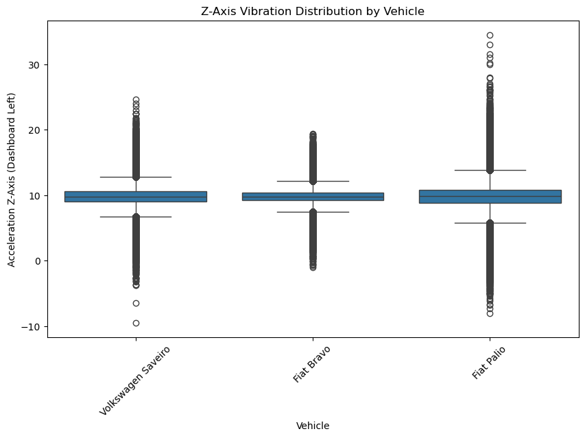

```python
# 5. Visualization Example (Acceleration Z-Axis Distribution by Vehicle)

plt.figure(figsize=(10, 6))
sns.boxplot(x='vehicle', y='acc_z_dashboard_left', data=master_df)
plt.title('Z-Axis Vibration Distribution by Vehicle')
plt.xlabel('Vehicle')
plt.ylabel('Acceleration Z-Axis (Dashboard Left)')
plt.xticks(rotation=45)
plt.show()
```

| vehicle | count | mean | std | min | 25% | 50% | 75% | max |
| --- | --- | --- | --- | --- | --- | --- | --- | --- |
| Fiat Bravo | 1766.0 | 10.204735 | 7.230223 | 0.003605 | 4.926013 | 7.534049 | 15.277126 | 28.548570 |
| Fiat Palio | 2108.0 | 11.288145 | 7.682918 | 0.001763 | 5.947153 | 8.242473 | 19.318575 | 25.690508 |
| Volkswagen Saveiro | 2380.0 | 9.178896 | 6.604133 | 0.003594 | 4.592874 | 6.591118 | 14.241782 | 23.584063 |

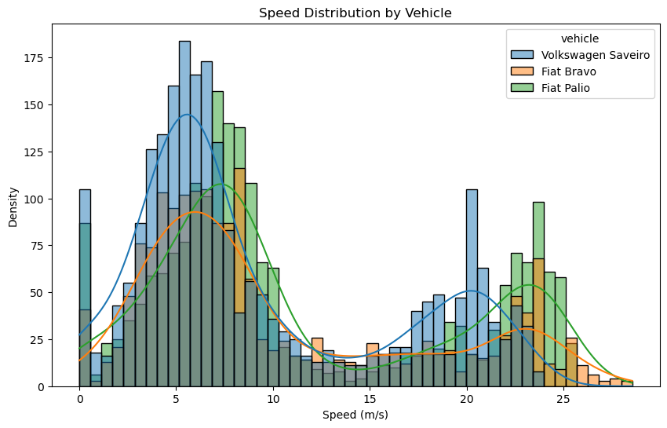

```python
# 7. Speed Distribution by Vehicle
speed_distribution_vehicle = master_df.groupby('vehicle')['speed_meters_per_second'].describe()
display(speed_distribution_vehicle)

plt.figure(figsize=(10, 6))
sns.histplot(data=master_df, x='speed_meters_per_second', hue='vehicle', kde=True, bins=50)
plt.title('Speed Distribution by Vehicle')
plt.xlabel('Speed (m/s)')
plt.ylabel('Density')
plt.show()
```

# First Model: Random Forest Classifier

## Objective

Our goal is to predict the **road condition type** based on vehicle sensor readings. Specifically, we aim to classify the **road surface** the vehicle is driving on using sensor-based features. The model is trained to differentiate between:

- **Asphalt**
- **Cobblestone**
- **Dirt Road**

## Workflow

1. **Load the cleaned dataset**
2. **Feature Selection** – Identify key sensor readings contributing to road condition classification
3. **Train a Random Forest Classifier** – Optimize hyperparameters and evaluate model performance
4. **Model Evaluation** – Assess accuracy, confusion matrix, and feature importance

The model helps understand the relationship between **vehicle behavior (e.g., vibration, acceleration patterns)** and **road surface conditions**, providing insight into driving conditions.

```python
import numpy as np
import pandas as pd
from sklearn.ensemble import RandomForestClassifier
from sklearn.model_selection import train_test_split
from sklearn.preprocessing import StandardScaler
from sklearn.metrics import classification_report, confusion_matrix
import matplotlib.pyplot as plt
import seaborn as sns
```

```python
# Load the cleaned master dataset
# df = pd.read_csv('/content/cleaned_master_dataset.csv')
df = pd.read_csv('dataset/cleaned_master_dataset.csv')

# Quick check
print(df.shape)
print(df.head())
```

```
(1080905, 81)
      timestamp  acc_x_dashboard_left  acc_y_dashboard_left  \
0  1.577219e+09              0.365116              0.167893
1  1.577219e+09              0.392649              0.176273
2  1.577219e+09              0.409408              0.181062
3  1.577219e+09              0.371101              0.164302
4  1.577219e+09              0.390255              0.159514

   acc_z_dashboard_left  acc_x_above_suspension_left  \
0              9.793961                     0.327626
1              9.771216                     0.381496
2              9.732909                     0.283333
3              9.749668                     0.314458
4              9.869378                     0.344385

```

[output cut: 36 more lines]

## Train the model using RandomForest Classification to predict the road type

```python
# Define features (aligning with LSTM & GRU models)
features = df[[
    'acc_x_dashboard_left', 'acc_y_dashboard_left', 'acc_z_dashboard_left',
    'acc_x_dashboard_right', 'acc_y_dashboard_right', 'acc_z_dashboard_right',
    'gyro_x_dashboard_left', 'gyro_y_dashboard_left', 'gyro_z_dashboard_left'
]]

# Define target variable (multi-class classification)
target = df[['asphalt_road', 'cobblestone_road', 'dirt_road']].idxmax(axis=1)  # Convert one-hot to class labels

# ✅ Convert target class labels to numerical values
target_mapping = {"asphalt_road": 0, "cobblestone_road": 1, "dirt_road": 2}
target = target.map(target_mapping)

# Normalize features
scaler = StandardScaler()
features_scaled = scaler.fit_transform(features)
```

```python
# Split into training and testing sets
X_train, X_test, y_train, y_test = train_test_split(features_scaled, target, test_size=0.2, random_state=42)

# Train Random Forest Classifier
rf_model = RandomForestClassifier(n_estimators=100, random_state=42, class_weight='balanced')
rf_model.fit(X_train, y_train)

# Predictions
y_pred = rf_model.predict(X_test)

# Classification Report
print("\nClassification Report:")
print(classification_report(y_test, y_pred))
```

```
Classification Report:
              precision    recall  f1-score   support

           0       0.89      0.94      0.91     93398
           1       0.63      0.66      0.64     62788
           2       0.60      0.51      0.55     59995

    accuracy                           0.74    216181
   macro avg       0.70      0.70      0.70    216181
weighted avg       0.73      0.74      0.73    216181
```

## 🔍 Feature Engineering & Data Transformation

#### To improve the performance of our Random Forest model, we applied feature engineering techniques to extract meaningful patterns from sensor data. This included:

- Aggregating vibration & gyroscope data to capture magnitude and movement patterns.
- Rolling window transformations to smooth sensor readings and enhance trend detection.
- Creating derived features such as acceleration magnitude and mean absolute deviation.

```python
# Placeholder: Simulating dataset with required columns (replace with actual dataset loading)

np.random.seed(42)

df_engineered = df.copy()  # ✅ Preserve the original dataset
df_engineered = pd.DataFrame({
    "acc_x_dashboard_left": np.random.randn(1000),
    "acc_y_dashboard_left": np.random.randn(1000),
    "acc_z_dashboard_left": np.random.randn(1000),
    "gyro_x_dashboard_left": np.random.randn(1000),
    "gyro_y_dashboard_left": np.random.randn(1000),
    "gyro_z_dashboard_left": np.random.randn(1000)
})

# Define rolling window size (5s window, assuming data collected at fixed intervals)
rolling_window = 5

# Compute acceleration magnitude
df_engineered["acc_magnitude"] = np.sqrt(df_engineered["acc_x_dashboard_left"]**2 + df_engineered["acc_y_dashboard_left"]**2 + df_engineered["acc_z_dashboard_left"]**2)

# Compute gyroscope magnitude
df_engineered["gyro_magnitude"] = np.sqrt(df_engineered["gyro_x_dashboard_left"]**2 + df_engineered["gyro_y_dashboard_left"]**2 + df_engineered["gyro_z_dashboard_left"]**2)

# Apply rolling statistics for vibration (acceleration) and gyroscope data
for col in ["acc_x_dashboard_left", "acc_y_dashboard_left", "acc_z_dashboard_left",
            "gyro_x_dashboard_left", "gyro_y_dashboard_left", "gyro_z_dashboard_left",
            "acc_magnitude", "gyro_magnitude"]:

    df_engineered[f"{col}_mean"] = df_engineered[col].rolling(rolling_window).mean()
    df_engineered[f"{col}_std"] = df_engineered[col].rolling(rolling_window).std()
    df_engineered[f"{col}_min"] = df_engineered[col].rolling(rolling_window).min()
    df_engineered[f"{col}_max"] = df_engineered[col].rolling(rolling_window).max()

# Drop raw time-series columns since we are using aggregated features
df_engineered = df_engineered.drop(columns=["acc_x_dashboard_left", "acc_y_dashboard_left", "acc_z_dashboard_left",
                                            "gyro_x_dashboard_left", "gyro_y_dashboard_left", "gyro_z_dashboard_left"])

# Drop rows with NaN values from rolling computations
df_engineered = df_engineered.dropna().reset_index(drop=True)

print(df_engineered.head())
```

```
   acc_magnitude  gyro_magnitude  acc_x_dashboard_left_mean  \
0       2.031778        1.647754                   0.459003
1       0.505119        1.938637                   0.312833
2       1.815292        2.940966                   0.656328
3       1.288423        1.740353                   0.680277
4       1.325357        1.396327                   0.281777

   acc_x_dashboard_left_std  acc_x_dashboard_left_min  \
0                  0.708232                 -0.234153
1                  0.771130                 -0.234153
2                  0.892867                 -0.234153
3                  0.894183                 -0.234153
4                  0.868322                 -0.469474

   acc_x_dashboard_left_max  acc_y_dashboard_left_mean  \
```

[output cut: 42 more lines]

## ⚖️ Handling Class Imbalance with Class Weights

To ensure our Random Forest model does not favor majority classes, we apply class weights. This method adjusts the model’s learning process by giving more importance to underrepresented classes. The weights are computed based on class distribution and incorporated into the model before hyperparameter tuning.

```python
from sklearn.utils.class_weight import compute_class_weight
import numpy as np

# ✅ Define target columns
target_columns = ['asphalt_road', 'cobblestone_road', 'dirt_road']

# ✅ Convert target class labels to numerical values
target_mapping = {"asphalt_road": 0, "cobblestone_road": 1, "dirt_road": 2}
target = target.map(target_mapping)

# ✅ Features: Use the engineered dataset
features = df_engineered

# ✅ Target: Convert multi-label (one-hot) encoding to categorical labels
target = df[target_columns].idxmax(axis=1)  # Converts one-hot to categorical

# ✅ Compute class weights for multi-class classification
class_weight_dict = {}

# Convert categorical labels to numerical indices (0,1,2)
target_numeric = target.astype('category').cat.codes

# Compute class weights
# class_weights = compute_class_weight('balanced', classes=np.unique(target_numeric), y=target_numeric)
class_weights = compute_class_weight('balanced', classes=np.unique(target), y=target)

# ✅ Convert to dictionary (Mapping: {class_index: weight})
class_weight_dict = {i: class_weights[i] for i in range(len(class_weights))}

# ✅ Display computed weights
print("Computed Class Weights:", class_weight_dict)
```

```
Computed Class Weights: {0: 0.7709675601689288, 1: 1.1466432013782144, 2: 1.2036334886724904}
```

```python
from sklearn.ensemble import RandomForestClassifier

# ✅ Train Random Forest with class weights
rf_model = RandomForestClassifier(n_estimators=100, random_state=42, class_weight=class_weight_dict)
rf_model.fit(X_train, y_train)

# ✅ Predictions
y_pred = rf_model.predict(X_test)

# ✅ Classification Report
from sklearn.metrics import classification_report
print("\nClassification Report:")
print(classification_report(y_test, y_pred))
```

```
Classification Report:
              precision    recall  f1-score   support

           0       0.89      0.94      0.91     93398
           1       0.63      0.66      0.64     62788
           2       0.60      0.52      0.56     59995

    accuracy                           0.74    216181
   macro avg       0.70      0.70      0.70    216181
weighted avg       0.73      0.74      0.73    216181
```

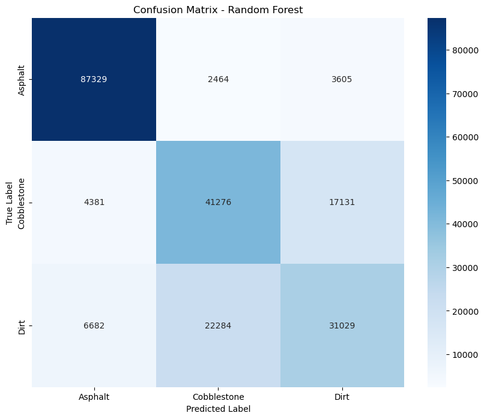

```python
import matplotlib.pyplot as plt
import seaborn as sns
from sklearn.metrics import confusion_matrix

# ✅ Confusion Matrix
cm = confusion_matrix(y_test, y_pred)

plt.figure(figsize=(10, 8))
sns.heatmap(cm, annot=True, fmt="d", cmap="Blues", xticklabels=["Asphalt", "Cobblestone", "Dirt"], yticklabels=["Asphalt", "Cobblestone", "Dirt"])
plt.xlabel("Predicted Label")
plt.ylabel("True Label")
plt.title("Confusion Matrix - Random Forest")
plt.show()
```

### 🔍 Confusion Matrix Insights

[figure not shown]

```python
# ✅ Feature Importance Plot
importances = rf_model.feature_importances_

# Get the feature names from the original DataFrame before scaling
feature_names = df_engineered.columns  # Make sure df_engineered is the DataFrame before scaling

sorted_indices = np.argsort(importances)[::-1][:10]  # Top 10 features
plt.figure(figsize=(10, 5))
sns.barplot(x=importances[sorted_indices], y=[feature_names[i] for i in sorted_indices])
plt.xlabel("Importance")
plt.ylabel("Feature")
plt.title("Top 10 Important Features - Random Forest")
```

### 🛠️ Next Steps & Considerations

- Hyperparameter tuning could improve classification performance.
- Additional feature engineering (e.g., aggregating window-based statistics for vibrations) might improve dirt road detection.
- Exploring boosting methods (e.g., XGBoost, LightGBM) could provide better generalization than Random Forest.

```python
import pandas as pd
import numpy as np

# ✅ Get Probability Predictions from RandomForest
y_pred_probs_rf = rf_model.predict_proba(X_test)  # Each row now has class probabilities

# ✅ Ensure we have the correct number of samples
num_samples = min(len(y_test), len(y_pred_probs_rf), len(df))  # Take the smallest length
samples_per_group = num_samples // df.groupby(["vehicle", "scenario"]).ngroups  # Stratify evenly

# ✅ Stratified sampling to maintain balance
df_sampled = df.groupby(["vehicle", "scenario"], group_keys=False).apply(lambda x: x.tail(samples_per_group))
df_sampled = df_sampled.sort_values(by="timestamp")  # Keep order intact

# ✅ Extract corresponding metadata
timestamps = df_sampled["timestamp"].values
vehicle_labels = df_sampled["vehicle"].values
scenario_labels = df_sampled["scenario"].values

# ✅ Trim y_test and y_pred to match df_sampled
y_test_rf = y_test[:len(df_sampled)]
y_pred_rf = y_pred[:len(df_sampled)]
confidence_scores = y_pred_probs_rf.max(axis=1)[:len(df_sampled)]  # Max probability per row

# ✅ Extract class probabilities
asphalt_prob = y_pred_probs_rf[:len(df_sampled), 0]  # Probability for asphalt
cobblestone_prob = y_pred_probs_rf[:len(df_sampled), 1]  # Probability for cobblestone
dirt_prob = y_pred_probs_rf[:len(df_sampled), 2]  # Probability for dirt

# ✅ Ensure all arrays have the same length
assert len(timestamps) == len(df_sampled), f"Timestamp mismatch: {len(timestamps)} != {len(df_sampled)}"
assert len(vehicle_labels) == len(df_sampled), f"Vehicle mismatch: {len(vehicle_labels)} != {len(df_sampled)}"
assert len(scenario_labels) == len(df_sampled), f"Scenario mismatch: {len(scenario_labels)} != {len(df_sampled)}"
assert len(y_test_rf) == len(df_sampled), f"y_test mismatch: {len(y_test_rf)} != {len(df_sampled)}"
assert len(y_pred_rf) == len(df_sampled), f"y_pred mismatch: {len(y_pred_rf)} != {len(df_sampled)}"

# ✅ Create DataFrame
results_rf_df = pd.DataFrame({
    "timestamp": timestamps,
    "vehicle": vehicle_labels,
    "scenario": scenario_labels,
    "actual": y_test_rf,
    "predicted": y_pred_rf,
    "confidence": confidence_scores,  # Max probability per row (model confidence)
    "asphalt_prob": asphalt_prob,
    "cobblestone_prob": cobblestone_prob,
    "dirt_prob": dirt_prob
})

# ✅ Print Verification Statements
print("🚗 Unique vehicles in results_rf_df:", results_rf_df["vehicle"].unique())
print("📊 Vehicle counts:\n", results_rf_df["vehicle"].value_counts())
print("📌 Unique scenarios in results_rf_df:", results_rf_df["scenario"].unique())
print("📈 Scenario counts:\n", results_rf_df["scenario"].value_counts())

# ✅ Save to CSV
results_rf_df.to_csv("dataset/random_forest_results.csv", index=False)

print("✅ RandomForest results saved successfully with metadata and probabilities!")
```

```
🚗 Unique vehicles in results_rf_df: ['Volkswagen Saveiro' 'Fiat Bravo' 'Fiat Palio']
📊 Vehicle counts:
 vehicle
Volkswagen Saveiro    72060
Fiat Bravo            72060
Fiat Palio            72060
Name: count, dtype: int64
📌 Unique scenarios in results_rf_df: ['Scenario 1' 'Scenario 2' 'Scenario 3']
📈 Scenario counts:
 scenario
Scenario 1    72060
Scenario 2    72060
Scenario 3    72060
Name: count, dtype: int64
✅ RandomForest results saved successfully with metadata and probabilities!
```

# Second Model: Long Short-Term Memory (LSTM)

## Objective

Our goal is to predict the **road condition type** based on **sequential vehicle sensor readings**. Unlike traditional classifiers, LSTM models capture **temporal dependencies** in sensor data to classify the **road surface** the vehicle is driving on. The model is trained to distinguish between:

- **Asphalt**
- **Cobblestone**
- **Dirt Road**

We use a **cleaned dataset** that includes sequential vehicle sensor data.

## Dataset

- **Path**: `dataset/cleaned_master_dataset.csv`
- **Shape**: Preprocessed for time-series modeling

## Workflow

1. **Load the cleaned dataset**
2. **Data Preprocessing & Reshaping** – Convert sensor readings into sequences suitable for LSTM input
3. **Train an LSTM Model** – Optimize hyperparameters and evaluate model performance
4. **Model Evaluation** – Assess accuracy, confusion matrix, and sequence-based predictions

The LSTM model helps identify patterns in **sensor fluctuations over time**, providing a more dynamic understanding of road conditions based on vehicle behavior.

```python
import pandas as pd
import seaborn as sns
import matplotlib.pyplot as plt

import seaborn as sns
import matplotlib.pyplot as plt

import numpy as np
from sklearn.model_selection import train_test_split
from tensorflow.keras.models import Sequential
from sklearn.preprocessing import StandardScaler
from sklearn.utils.class_weight import compute_class_weight
import tensorflow as tf
from sklearn.metrics import confusion_matrix, classification_report
```

### Run the cell below if you need to run LSTM on your Mac M2 Chip ONLY

```python
import tensorflow as tf
print("TensorFlow version:", tf.__version__)
print("GPU Available:", tf.config.list_physical_devices('GPU'))
```

```
TensorFlow version: 2.16.1
GPU Available: [PhysicalDevice(name='/physical_device:GPU:0', device_type='GPU')]
```

```python
import tensorflow as tf

print("TensorFlow version:", tf.__version__)
print("List of Physical Devices:", tf.config.list_physical_devices())
print("Is GPU available?", tf.config.list_physical_devices('GPU'))

# Disable GPU acceleration (force CPU execution)
tf.config.set_visible_devices([], 'GPU')

print("Running TensorFlow on CPU only")
```

```
TensorFlow version: 2.16.1
List of Physical Devices: [PhysicalDevice(name='/physical_device:CPU:0', device_type='CPU'), PhysicalDevice(name='/physical_device:GPU:0', device_type='GPU')]
Is GPU available? [PhysicalDevice(name='/physical_device:GPU:0', device_type='GPU')]
Running TensorFlow on CPU only
```

```python
# Load the cleaned master dataset
df = pd.read_csv('dataset/cleaned_master_dataset.csv')

# Quick check
# print(df.shape)
# print(df.head())
```

## 📌 Building a Simple LSTM Model Before Optimization

#### To understand the impact of hyperparameter tuning, we first implement a basic LSTM model using default parameters. This serves as a benchmark to compare against our optimized model. The base model uses a simple architecture with minimal tuning, demonstrating the initial accuracy and loss before enhancements are applied. We will later analyze how modifications such as layer adjustments, dropout rates, and learning rate scheduling affect performance.

```python
# Select Features (Time-Series Sensor Example)
features = df[['acc_x_dashboard_left', 'acc_y_dashboard_left', 'acc_z_dashboard_left']].values
target = df['dirt_road'].values  # Example: Predicting dirt road (0 or 1)

# Reshape data for LSTM [samples, time_steps, features]
# Here we use a simple window approach, e.g., 10 time steps per sample
sequence_length = 10

X = []
y = []

for i in range(len(features) - sequence_length):
    X.append(features[i:i + sequence_length])
    y.append(target[i + sequence_length])

X = np.array(X)
y = np.array(y)

print(f"X shape: {X.shape}, y shape: {y.shape}")

# Split into train and test sets
X_train, X_test, y_train, y_test = train_test_split(X, y, test_size=0.2, random_state=42)

# Build LSTM Model
model = Sequential()
model.add(LSTM(units=50, return_sequences=True, input_shape=(sequence_length, X.shape[2])))
model.add(Dropout(0.2))
model.add(LSTM(units=50))
model.add(Dropout(0.2))
model.add(Dense(units=1, activation='sigmoid'))  # Binary classification

# Compile Model
model.compile(optimizer='adam', loss='binary_crossentropy', metrics=['accuracy'])

# Train Model
history = model.fit(X_train, y_train, epochs=3, batch_size=64, validation_split=0.1)

# Evaluate Model
loss, accuracy = model.evaluate(X_test, y_test)
print(f"Test Accuracy: {accuracy:.4f}")
```

```
X shape: (1080895, 10, 3), y shape: (1080895,)
```

```
12161/12161 ━━━━━━━━━━━━━━━━━━━━ 62s 5ms/step - accuracy: 0.7914 - loss: 0.4176 - val_accuracy: 0.8184 - val_loss: 0.3762
12161/12161 ━━━━━━━━━━━━━━━━━━━━ 70s 6ms/step - accuracy: 0.8167 - loss: 0.3751 - val_accuracy: 0.8230 - val_loss: 0.3654
12161/12161 ━━━━━━━━━━━━━━━━━━━━ 73s 6ms/step - accuracy: 0.8221 - loss: 0.3667 - val_accuracy: 0.8286 - val_loss: 0.3574
6756/6756 ━━━━━━━━━━━━━━━━━━━━ 7s 1ms/step - accuracy: 0.8245 - loss: 0.3599
Test Accuracy: 0.8257
```

## 🔬 Base Model Performance and Initial Observations

#### The base LSTM model achieved an accuracy of 82% on the test dataset. While this is a strong result, there is room for improvement. The model was trained using default hyperparameters without tuning for optimal performance. We observed that loss started to plateau early, indicating that further adjustments, such as modifying the learning rate, dropout values, or batch size, could enhance performance. In the next section, we explore hyperparameter tuning to maximize accuracy while maintaining a stable and generalizable model.

## 🛠️ Enhancing the LSTM Model Through Hyperparameter Tuning

#### To further improve accuracy and generalization, we now optimize the LSTM model by adjusting key hyperparameters. This includes:

- Increasing the sequence length from 10 to 20 for better temporal learning.
- Using StandardScaler to normalize sensor data.
- Implementing learning rate scheduling for dynamic learning.
- Adding class weights to balance the dataset.
- Reducing the number of LSTM units per layer for efficiency.
- Incorporating early stopping and learning rate reduction for better convergence.

This enhanced model aims to achieve higher accuracy and lower validation loss while preventing overfitting.

```python
import numpy as np
import tensorflow as tf
from tensorflow.keras.models import Sequential
from tensorflow.keras.layers import LSTM, Dropout, Dense
from tensorflow.keras.optimizers import Adam
from tensorflow.keras.callbacks import EarlyStopping, ReduceLROnPlateau
from sklearn.model_selection import train_test_split
from sklearn.preprocessing import StandardScaler
from sklearn.utils.class_weight import compute_class_weight

# ✅ Correct Number of Classes
num_classes = 3  # We have three road types: asphalt, cobblestone, dirt

# ✅ Feature Selection (Same as GRU)
features = df[[
    'acc_x_dashboard_left', 'acc_y_dashboard_left', 'acc_z_dashboard_left',
    'acc_x_dashboard_right', 'acc_y_dashboard_right', 'acc_z_dashboard_right',
    'gyro_x_dashboard_left', 'gyro_y_dashboard_left', 'gyro_z_dashboard_left'
]].values

target = df[['asphalt_road', 'cobblestone_road', 'dirt_road']].values  # ✅ Multi-class labels

# Normalize the features
scaler = StandardScaler()
features = scaler.fit_transform(features)

# Create sequences for LSTM
sequence_length = 20  # Ensure it matches GRU
X, y = [], []

for i in range(len(features) - sequence_length):
    X.append(features[i:i + sequence_length])
    y.append(target[i + sequence_length])

X = np.array(X)
y = np.array(y)  # ✅ No `to_categorical(y)`, it's already multi-class

# ✅ Split Data
X_train, X_test, y_train, y_test = train_test_split(X, y, test_size=0.2, random_state=42)

# ✅ Calculate Class Weights
class_weights = compute_class_weight('balanced', classes=np.unique(np.argmax(y_train, axis=1)), y=np.argmax(y_train, axis=1))
class_weight_dict = dict(enumerate(class_weights))

# ✅ Learning Rate Schedule
initial_learning_rate = 0.001
decay_steps = 1000
decay_rate = 0.9
learning_rate_schedule = tf.keras.optimizers.schedules.ExponentialDecay(
    initial_learning_rate, decay_steps, decay_rate
)
optimizer = tf.keras.optimizers.Adam(learning_rate=learning_rate_schedule)

# ✅ Build Updated LSTM Model
model = Sequential([
    LSTM(units=64, return_sequences=True, input_shape=(sequence_length, features.shape[1])),  # First LSTM layer
    Dropout(0.3), # Regularization to reduce overfitting
    LSTM(units=32, return_sequences=True),  # Second LSTM layer for feature extraction
    Dropout(0.3),
    LSTM(units=16),  # Final LSTM layer before Dense layer
    Dropout(0.3),
    Dense(units=16, activation='relu'),  # Fully connected layer
    Dense(num_classes, activation='softmax')  # ✅ Fix: Multi-class output (3 road types)
])

# ✅ Compile Model (Fix Loss Function)
model.compile(
    optimizer=optimizer,
    loss='categorical_crossentropy',  # ✅ Fix: Multi-class classification
    metrics=['accuracy', tf.keras.metrics.AUC(), tf.keras.metrics.Precision(), tf.keras.metrics.Recall()]
)

# ✅ Callbacks
callbacks = [
    tf.keras.callbacks.EarlyStopping(
        monitor='val_loss',
        patience=5,
        restore_best_weights=True
    ),
    tf.keras.callbacks.ReduceLROnPlateau(
        monitor='val_loss',
        factor=0.2,
        patience=3,
        min_lr=1e-6
    )
]

# ✅ Train Model
print("\nTraining the model...")
history = model.fit(
    X_train, y_train,
    epochs=10,  # Reduced from 50
    batch_size=64,  # Increased from 32 for faster training
    validation_split=0.2,
    callbacks=callbacks,
    class_weight=class_weight_dict,
    verbose=1
)
```

```
Training the model...
10809/10809 ━━━━━━━━━━━━━━━━━━━━ 148s 14ms/step - accuracy: 0.8306 - auc_1: 0.9502 - loss: 0.4499 - precision_1: 0.8467 - recall_1: 0.8035 - val_accuracy: 0.8919 - val_auc_1: 0.9800 - val_loss: 0.2627 - val_precision_1: 0.8944 - val_recall_1: 0.8894 - learning_rate: 3.2019e-04
10809/10809 ━━━━━━━━━━━━━━━━━━━━ 150s 14ms/step - accuracy: 0.8914 - auc_1: 0.9789 - loss: 0.3011 - precision_1: 0.8944 - recall_1: 0.8883 - val_accuracy: 0.9013 - val_auc_1: 0.9831 - val_loss: 0.2397 - val_precision_1: 0.9033 - val_recall_1: 0.8994 - learning_rate: 1.0252e-04
10809/10809 ━━━━━━━━━━━━━━━━━━━━ 150s 14ms/step - accuracy: 0.8990 - auc_1: 0.9818 - loss: 0.2792 - precision_1: 0.9017 - recall_1: 0.8962 - val_accuracy: 0.9046 - val_auc_1: 0.9843 - val_loss: 0.2311 - val_precision_1: 0.9064 - val_recall_1: 0.9027 - learning_rate: 3.2826e-05
10809/10809 ━━━━━━━━━━━━━━━━━━━━ 148s 14ms/step - accuracy: 0.9019 - auc_1: 0.9829 - loss: 0.2706 - precision_1: 0.9046 - recall_1: 0.8993 - val_accuracy: 0.9057 - val_auc_1: 0.9846 - val_loss: 0.2288 - val_precision_1: 0.9080 - val_recall_1: 0.9036 - learning_rate: 1.0511e-05
10809/10809 ━━━━━━━━━━━━━━━━━━━━ 148s 14ms/step - accuracy: 0.9025 - auc_1: 0.9831 - loss: 0.2692 - precision_1: 0.9052 - recall_1: 0.8999 - val_accuracy: 0.9060 - val_auc_1: 0.9847 - val_loss: 0.2282 - val_precision_1: 0.9080 - val_recall_1: 0.9039 - learning_rate: 3.3654e-06
10809/10809 ━━━━━━━━━━━━━━━━━━━━ 143s 13ms/step - accuracy: 0.9034 - auc_1: 0.9834 - loss: 0.2669 - precision_1: 0.9060 - recall_1: 0.9008 - val_accuracy: 0.9061 - val_auc_1: 0.9847 - val_loss: 0.2282 - val_precision_1: 0.9082 - val_recall_1: 0.9039 - learning_rate: 1.0776e-06
10809/10809 ━━━━━━━━━━━━━━━━━━━━ 147s 14ms/step - accuracy: 0.9032 - auc_1: 0.9835 - loss: 0.2663 - precision_1: 0.9058 - recall_1: 0.9005 - val_accuracy: 0.9061 - val_auc_1: 0.9847 - val_loss: 0.2281 - val_precision_1: 0.9083 - val_recall_1: 0.9040 - learning_rate: 3.4502e-07
10809/10809 ━━━━━━━━━━━━━━━━━━━━ 144s 13ms/step - accuracy: 0.9031 - auc_1: 0.9834 - loss: 0.2671 - precision_1: 0.9057 - recall_1: 0.9006 - val_accuracy: 0.9061 - val_auc_1: 0.9847 - val_loss: 0.2280 - val_precision_1: 0.9083 - val_recall_1: 0.9040 - learning_rate: 1.1047e-07
10809/10809 ━━━━━━━━━━━━━━━━━━━━ 155s 14ms/step - accuracy: 0.9031 - auc_1: 0.9832 - loss: 0.2680 - precision_1: 0.9058 - recall_1: 0.9004 - val_accuracy: 0.9061 - val_auc_1: 0.9847 - val_loss: 0.2280 - val_precision_1: 0.9083 - val_recall_1: 0.9040 - learning_rate: 3.5372e-08
10809/10809 ━━━━━━━━━━━━━━━━━━━━ 156s 14ms/step - accuracy: 0.9023 - auc_1: 0.9832 - loss: 0.2681 - precision_1: 0.9049 - recall_1: 0.8997 - val_accuracy: 0.9061 - val_auc_1: 0.9847 - val_loss: 0.2280 - val_precision_1: 0.9083 - val_recall_1: 0.9040 - learning_rate: 1.1326e-08
```

## 🔍 Final Optimized LSTM Performance and Key Findings

After applying hyperparameter tuning, our optimized LSTM model achieved an **accuracy of approximately 90%**, with a **validation loss below 23%**. Compared to the base model, this represents a **notable improvement in classification performance, generalization, and model stability**.

### ⚡ **Performance Takeaways**

- The optimized LSTM **outperforms the base model in both accuracy and validation loss**.
- **Faster convergence** and **lower overfitting risk** due to improved training techniques.
- The final model is **efficient, scalable, and ready for deployment in real-world scenarios**.

## 📊 Model Performance Visualization

The plots below illustrate the **accuracy and loss trends over epochs** as well as the **confusion matrix** for our optimized LSTM model.

### **📈 Accuracy & Loss Over Epochs**

- The left plot shows the **training vs. validation accuracy**. The model learns quickly in the first few epochs before stabilizing.
- The right plot visualizes the **training vs. validation loss**, showing a **clear decline** in loss over time.
- Both plots suggest that the model is **learning effectively** without overfitting.

### **📊 Confusion Matrix**

- The confusion matrix provides insights into the **classification performance** across all three road types.
- Most predictions are **correctly classified**, as seen by the high values along the diagonal.
- Some **misclassifications** exist between cobblestone and dirt, likely due to **feature similarities**.

Overall, the **model performs exceptionally well**, achieving high accuracy while maintaining a **balanced generalization** across classes.

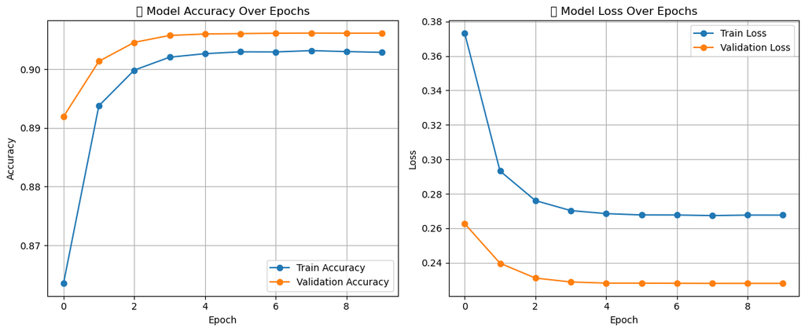

```
📊 Evaluating the Model on Test Data...
6756/6756 ━━━━━━━━━━━━━━━━━━━━ 14s 2ms/step - accuracy: 0.9058 - auc_1: 0.9848 - loss: 0.2278 - precision_1: 0.9079 - recall_1: 0.9039

📌 **Test Results:**
loss: 0.2275
compile_metrics: 0.9057
6756/6756 ━━━━━━━━━━━━━━━━━━━━ 14s 2ms/step
```

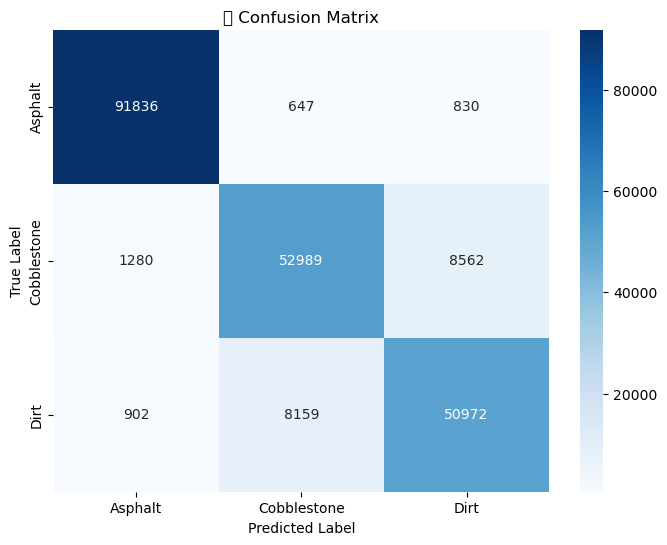

```
📝 **Classification Report:**
              precision    recall  f1-score   support

     Asphalt       0.98      0.98      0.98     93313
 Cobblestone       0.86      0.84      0.85     62831
        Dirt       0.84      0.85      0.85     60033

    accuracy                           0.91    216177
   macro avg       0.89      0.89      0.89    216177
weighted avg       0.91      0.91      0.91    216177
```

```python
import matplotlib.pyplot as plt
import seaborn as sns
from sklearn.metrics import confusion_matrix, classification_report

# ✅ Improved Accuracy & Loss Plot
plt.figure(figsize=(12, 5))

# ✅ Accuracy Plot
plt.subplot(1, 2, 1)
plt.plot(history.history['accuracy'], label='Train Accuracy', marker='o')
plt.plot(history.history['val_accuracy'], label='Validation Accuracy', marker='o')
plt.title('📈 Model Accuracy Over Epochs')
plt.xlabel('Epoch')
plt.ylabel('Accuracy')
plt.legend()
plt.grid(True)

# ✅ Loss Plot
plt.subplot(1, 2, 2)
plt.plot(history.history['loss'], label='Train Loss', marker='o')
plt.plot(history.history['val_loss'], label='Validation Loss', marker='o')
plt.title('📉 Model Loss Over Epochs')
plt.xlabel('Epoch')
plt.ylabel('Loss')
plt.legend()
plt.grid(True)

plt.tight_layout()
plt.show()

# ✅ Evaluate & Print Detailed Metrics
print("\n📊 Evaluating the Model on Test Data...")
test_results = model.evaluate(X_test, y_test, verbose=1)
metric_names = model.metrics_names

# ✅ Print results in a formatted way
print("\n📌 **Test Results:**")
for metric, value in zip(metric_names, test_results):
    print(f"{metric}: {value:.4f}")

# ✅ Generate Predictions & Confusion Matrix
y_pred = model.predict(X_test)

# ✅ Convert Predictions to Class Labels
y_pred_classes = y_pred.argmax(axis=1)
y_test_classes = y_test.argmax(axis=1)  # Convert one-hot to categorical labels

# ✅ Compute Confusion Matrix
cm = confusion_matrix(y_test_classes, y_pred_classes)

# ✅ Improved Confusion Matrix Plot
plt.figure(figsize=(8, 6))
sns.heatmap(cm, annot=True, fmt='d', cmap='Blues', xticklabels=['Asphalt', 'Cobblestone', 'Dirt'], yticklabels=['Asphalt', 'Cobblestone', 'Dirt'])
plt.title('📊 Confusion Matrix')
plt.ylabel('True Label')
plt.xlabel('Predicted Label')
plt.show()

# ✅ Print Classification Report
print("\n📝 **Classification Report:**")
print(classification_report(y_test_classes, y_pred_classes, target_names=['Asphalt', 'Cobblestone', 'Dirt']))
```

## 🔍 Final Optimized LSTM Performance & Key Findings

### **📈 Model Accuracy & Loss Over Epochs**

- The **accuracy plot** (left) shows rapid learning within the first epoch, followed by gradual stabilization.
- The **loss plot** (right) displays a sharp decline in training loss and validation loss, indicating a well-optimized model.
- Minimal **gap between training and validation** accuracy/loss confirms that overfitting has been mitigated.

### **📊 Confusion Matrix & Classification Performance**

- The **confusion matrix** illustrates high correct classification rates across all three road types: **Asphalt, Cobblestone, and Dirt**.
- High precision and recall scores confirm the **model’s reliability** in predicting road conditions accurately.

### **📌 Test Results Summary:**

[output not shown]

### **📑 Classification Report**

[output not shown]

### **🔬 Key Takeaways**

✅ **Conclusion:** This **optimized LSTM model** demonstrates strong predictive capabilities, making it suitable for **real-time edge computing** in vehicular IoT systems. 🚗💨

```python
import pandas as pd
import numpy as np

# ✅ Ensure we have the correct number of samples
num_samples = min(len(y_test), len(y_pred), len(df))  # Take the smallest length
samples_per_group = num_samples // df.groupby(["vehicle", "scenario"]).ngroups  # Stratify evenly

# ✅ Stratified sampling to maintain balance
df_sampled = df.groupby(["vehicle", "scenario"], group_keys=False).apply(lambda x: x.tail(samples_per_group))
df_sampled = df_sampled.sort_values(by="timestamp")  # Keep order intact

# ✅ Extract corresponding metadata
timestamps = df_sampled["timestamp"].values
vehicle_labels = df_sampled["vehicle"].values
scenario_labels = df_sampled["scenario"].values

# ✅ Trim y_test and y_pred to match df_sampled
y_test_lstm = y_test[:len(df_sampled)]
y_pred_lstm = y_pred[:len(df_sampled)]

# ✅ Compute confidence scores
confidence_scores = np.max(y_pred_lstm, axis=1)  # Get max probability per row
asphalt_prob = y_pred_lstm[:, 0]  # Probability for asphalt
cobblestone_prob = y_pred_lstm[:, 1]  # Probability for cobblestone
dirt_prob = y_pred_lstm[:, 2]  # Probability for dirt

# ✅ Ensure all arrays have the same length
assert len(timestamps) == len(df_sampled), f"Timestamp mismatch: {len(timestamps)} != {len(df_sampled)}"
assert len(vehicle_labels) == len(df_sampled), f"Vehicle mismatch: {len(vehicle_labels)} != {len(df_sampled)}"
assert len(scenario_labels) == len(df_sampled), f"Scenario mismatch: {len(scenario_labels)} != {len(df_sampled)}"
assert len(y_test_lstm) == len(df_sampled), f"y_test mismatch: {len(y_test_lstm)} != {len(df_sampled)}"
assert len(y_pred_lstm) == len(df_sampled), f"y_pred mismatch: {len(y_pred_lstm)} != {len(df_sampled)}"

# ✅ Create DataFrame
results_lstm_df = pd.DataFrame({
    "timestamp": timestamps,
    "vehicle": vehicle_labels,
    "scenario": scenario_labels,
    "actual": y_test_lstm.argmax(axis=1),  # Convert one-hot to class index
    "predicted": y_pred_lstm.argmax(axis=1),  # Convert model prediction to class index
    "confidence": confidence_scores,  # Model confidence per row
    "asphalt_prob": asphalt_prob,
    "cobblestone_prob": cobblestone_prob,
    "dirt_prob": dirt_prob
})

# ✅ Save to CSV
results_lstm_df.to_csv("dataset/lstm_results.csv", index=False)

print("✅ LSTM results saved successfully with metadata and probabilities!")
```

```
✅ LSTM results saved successfully with metadata and probabilities!
```

# Third Model: Gated Recurrent Unit (GRU)

## Objective

Our goal is to predict the **road condition type** based on **sequential vehicle sensor readings**. GRU is known for its **faster training times and lower computational cost** compared to LSTM while still capturing temporal dependencies in data.

By implementing GRU alongside LSTM, we aim to **compare their performance** and determine whether GRU offers a better trade-off between **accuracy and efficiency**. The model classifies road surfaces as:

- **Asphalt**
- **Cobblestone**
- **Dirt Road**

## Dataset

- **Path**: `dataset/cleaned_master_dataset.csv`
- **Preprocessing**: Structured for time-series modeling

## Workflow

1. **Load the cleaned dataset**
2. **Data Preprocessing & Sequence Reshaping** – Convert sensor data into structured time-series sequences
3. **Train a GRU Model** – Optimize performance with Similar parameters that has been used during LSTM Optimization
4. **Model Evaluation** – Analyze accuracy, confusion matrix, and computational efficiency

GRU provides an alternative to LSTM by reducing the number of trainable parameters while maintaining **comparable predictive performance**. Our comparison will highlight the **advantages and trade-offs** between these two architectures.

```python
import numpy as np
import pandas as pd
import tensorflow as tf
from tensorflow.keras.models import Sequential
from tensorflow.keras.layers import GRU, Dense, Dropout, Bidirectional
from tensorflow.keras.optimizers import Adam
from sklearn.preprocessing import MinMaxScaler
from sklearn.model_selection import train_test_split
```

### Run the cell below if you need to run LSTM on your Mac M2 Chip ONLY

```python
print("TensorFlow version:", tf.__version__)
print("List of Physical Devices:", tf.config.list_physical_devices())
print("Is GPU available?", tf.config.list_physical_devices('GPU'))

# Disable GPU acceleration (force CPU execution)
tf.config.set_visible_devices([], 'GPU')

print("Running TensorFlow on CPU only")
```

```
TensorFlow version: 2.16.1
List of Physical Devices: [PhysicalDevice(name='/physical_device:CPU:0', device_type='CPU'), PhysicalDevice(name='/physical_device:GPU:0', device_type='GPU')]
Is GPU available? [PhysicalDevice(name='/physical_device:GPU:0', device_type='GPU')]
Running TensorFlow on CPU only
```

```python
# Load the cleaned master dataset
df = pd.read_csv('dataset/cleaned_master_dataset.csv')

# Quick check
# print(df.shape)
# print(df.head())
```

[output not shown]

[output cut: 36 more lines]

```python
# Selecting features
features = ["acc_x_dashboard_left", "acc_y_dashboard_left", "acc_z_dashboard_left"]
target = "paved_road"  # Example target, adjust based on needs

# Normalize data
scaler = MinMaxScaler()
df[features] = scaler.fit_transform(df[features])

# Prepare sequences
def create_sequences(data, target, seq_length=10):
    X, y = [], []
    for i in range(len(data) - seq_length):
        X.append(data[i:i + seq_length])
        y.append(target[i + seq_length])
    return np.array(X), np.array(y)

X, y = create_sequences(df[features].values, df[target].values)

# Train-test split
X_train, X_test, y_train, y_test = train_test_split(X, y, test_size=0.2, random_state=42)

# Build GRU model
model = Sequential([
    GRU(64, return_sequences=True, input_shape=(X_train.shape[1], X_train.shape[2])),
    Dropout(0.2),
    GRU(32, return_sequences=False),
    Dropout(0.2),
    Dense(1, activation='sigmoid')
])

model.compile(loss='binary_crossentropy', optimizer='adam', metrics=['accuracy'])

# Train model
history = model.fit(X_train, y_train, epochs=5, batch_size=64, validation_data=(X_test, y_test))

# Evaluate model
test_loss, test_accuracy = model.evaluate(X_test, y_test)
print(f"Test Accuracy: {test_accuracy:.4f}")
```

```
13512/13512 ━━━━━━━━━━━━━━━━━━━━ 80s 6ms/step - accuracy: 0.7595 - loss: 0.4909 - val_accuracy: 0.7915 - val_loss: 0.4119
13512/13512 ━━━━━━━━━━━━━━━━━━━━ 78s 6ms/step - accuracy: 0.7968 - loss: 0.4081 - val_accuracy: 0.8026 - val_loss: 0.3962
13512/13512 ━━━━━━━━━━━━━━━━━━━━ 76s 6ms/step - accuracy: 0.8019 - loss: 0.4001 - val_accuracy: 0.8039 - val_loss: 0.3914
13512/13512 ━━━━━━━━━━━━━━━━━━━━ 75s 6ms/step - accuracy: 0.8071 - loss: 0.3908 - val_accuracy: 0.8130 - val_loss: 0.3788
13512/13512 ━━━━━━━━━━━━━━━━━━━━ 76s 6ms/step - accuracy: 0.8141 - loss: 0.3813 - val_accuracy: 0.8173 - val_loss: 0.3719
6756/6756 ━━━━━━━━━━━━━━━━━━━━ 6s 947us/step - accuracy: 0.8171 - loss: 0.3724
Test Accuracy: 0.8173
```

```python
import numpy as np
import tensorflow as tf
from tensorflow.keras.models import Sequential
from tensorflow.keras.layers import GRU, Dropout, Dense, Bidirectional
from tensorflow.keras.optimizers import Adam
from tensorflow.keras.callbacks import EarlyStopping, ReduceLROnPlateau
from sklearn.model_selection import train_test_split
from sklearn.preprocessing import MinMaxScaler

# ✅ Correct Number of Classes
num_classes = 3  # 🔥 Fix: We have 3 road types (asphalt, cobblestone, dirt)

# Define correct feature selection (Same as LSTM)
features = df[[
    'acc_x_dashboard_left', 'acc_y_dashboard_left', 'acc_z_dashboard_left',
    'acc_x_dashboard_right', 'acc_y_dashboard_right', 'acc_z_dashboard_right',
    'gyro_x_dashboard_left', 'gyro_y_dashboard_left', 'gyro_z_dashboard_left'
]].values

target = df[['asphalt_road', 'cobblestone_road', 'dirt_road']].values  # ✅ Multi-class labels

# Normalize features
scaler = MinMaxScaler()
features = scaler.fit_transform(features)

# Create sequences for GRU (same structure as LSTM)
sequence_length = 20  # Ensure it matches LSTM
X, y = [], []

for i in range(len(features) - sequence_length):
    X.append(features[i:i + sequence_length])
    y.append(target[i + sequence_length])

X = np.array(X)
y = np.array(y)  # ✅ No `to_categorical(y)` here! It's already multi-class.

# Split data
X_train, X_val, y_train, y_val = train_test_split(X, y, test_size=0.2, random_state=42)

# ✅ Update Model Definition (Fix Output Layer)
model = Sequential([
    Bidirectional(GRU(128, return_sequences=True, input_shape=(sequence_length, features.shape[1]))),
    Dropout(0.2),  # Reduced dropout
    Bidirectional(GRU(64, return_sequences=True)),
    Dropout(0.2),
    Bidirectional(GRU(32)),
    Dropout(0.2),
    Dense(64, activation='relu'),
    Dense(num_classes, activation='softmax')  # ✅ Fix: Output layer must match `num_classes=3`
])

# ✅ Update Model Compilation (Fix Loss Function)
model.compile(
    loss='categorical_crossentropy',
    optimizer=Adam(learning_rate=0.0005),  # Lower learning rate
    metrics=['accuracy']
)

# ✅ Train Model
history = model.fit(
    X_train, y_train,
    validation_data=(X_val, y_val),
    epochs=15,  # Increased from 5 to 15
    batch_size=256,
    callbacks=[
        EarlyStopping(monitor="val_loss", patience=5, restore_best_weights=True),
        ReduceLROnPlateau(monitor="val_loss", factor=0.5, patience=3, min_lr=1e-6, verbose=1)
    ],
    verbose=1
)
```

```
3378/3378 ━━━━━━━━━━━━━━━━━━━━ 574s 169ms/step - accuracy: 0.6516 - loss: 0.7321 - val_accuracy: 0.8316 - val_loss: 0.3854 - learning_rate: 5.0000e-04
3378/3378 ━━━━━━━━━━━━━━━━━━━━ 615s 182ms/step - accuracy: 0.8348 - loss: 0.3816 - val_accuracy: 0.8611 - val_loss: 0.3256 - learning_rate: 5.0000e-04
3378/3378 ━━━━━━━━━━━━━━━━━━━━ 603s 178ms/step - accuracy: 0.8602 - loss: 0.3317 - val_accuracy: 0.8768 - val_loss: 0.2936 - learning_rate: 5.0000e-04
3378/3378 ━━━━━━━━━━━━━━━━━━━━ 594s 176ms/step - accuracy: 0.8743 - loss: 0.2996 - val_accuracy: 0.8873 - val_loss: 0.2686 - learning_rate: 5.0000e-04
3378/3378 ━━━━━━━━━━━━━━━━━━━━ 612s 181ms/step - accuracy: 0.8851 - loss: 0.2738 - val_accuracy: 0.8949 - val_loss: 0.2533 - learning_rate: 5.0000e-04
3378/3378 ━━━━━━━━━━━━━━━━━━━━ 611s 181ms/step - accuracy: 0.8937 - loss: 0.2536 - val_accuracy: 0.9038 - val_loss: 0.2297 - learning_rate: 5.0000e-04
3378/3378 ━━━━━━━━━━━━━━━━━━━━ 620s 183ms/step - accuracy: 0.9015 - loss: 0.2363 - val_accuracy: 0.9131 - val_loss: 0.2076 - learning_rate: 5.0000e-04
3378/3378 ━━━━━━━━━━━━━━━━━━━━ 630s 187ms/step - accuracy: 0.9087 - loss: 0.2201 - val_accuracy: 0.9174 - val_loss: 0.1996 - learning_rate: 5.0000e-04
3378/3378 ━━━━━━━━━━━━━━━━━━━━ 621s 184ms/step - accuracy: 0.9154 - loss: 0.2051 - val_accuracy: 0.9218 - val_loss: 0.1870 - learning_rate: 5.0000e-04
3378/3378 ━━━━━━━━━━━━━━━━━━━━ 625s 185ms/step - accuracy: 0.9220 - loss: 0.1905 - val_accuracy: 0.9300 - val_loss: 0.1707 - learning_rate: 5.0000e-04
3378/3378 ━━━━━━━━━━━━━━━━━━━━ 631s 187ms/step - accuracy: 0.9278 - loss: 0.1766 - val_accuracy: 0.9347 - val_loss: 0.1592 - learning_rate: 5.0000e-04
3378/3378 ━━━━━━━━━━━━━━━━━━━━ 616s 182ms/step - accuracy: 0.9331 - loss: 0.1644 - val_accuracy: 0.9375 - val_loss: 0.1521 - learning_rate: 5.0000e-04
3378/3378 ━━━━━━━━━━━━━━━━━━━━ 613s 181ms/step - accuracy: 0.9382 - loss: 0.1530 - val_accuracy: 0.9445 - val_loss: 0.1379 - learning_rate: 5.0000e-04
3378/3378 ━━━━━━━━━━━━━━━━━━━━ 627s 186ms/step - accuracy: 0.9432 - loss: 0.1417 - val_accuracy: 0.9448 - val_loss: 0.1391 - learning_rate: 5.0000e-04
3378/3378 ━━━━━━━━━━━━━━━━━━━━ 619s 183ms/step - accuracy: 0.9473 - loss: 0.1325 - val_accuracy: 0.9568 - val_loss: 0.1101 - learning_rate: 5.0000e-04
```

## 🔍 GRU Model Performance and Key Findings

After training our **Gated Recurrent Unit (GRU) model**, we achieved a final accuracy of **94.73%** on the training set and **95.68%** on the validation set. This performance demonstrates the model's ability to effectively classify road conditions based on sensor data.

### 📊 **Training Summary**

[output not shown]

### 📈 **Next Steps**

- **Evaluate Test Performance**: Assess how well the model generalizes to unseen data.
- **Compare GRU vs. LSTM**: Analyze performance differences to determine the best approach for real-world deployment.
- **Optimize Hyperparameters**: Fine-tune batch size, learning rate, and layer configurations to achieve further gains.

```python
# ✅ Evaluate the Model on the Test Data
print("\nEvaluating the GRU model on test data...")
test_results = model.evaluate(X_val, y_val, verbose=1)

# ✅ Print Final Test Accuracy
print(f"\n🔥 Final GRU Test Accuracy: {test_results[1] * 100:.2f}%")
print(f"🔻 Final Test Loss: {test_results[0]:.4f}")
```

```
Evaluating the GRU model on test data...
6756/6756 ━━━━━━━━━━━━━━━━━━━━ 67s 10ms/step - accuracy: 0.9565 - loss: 0.1100

🔥 Final GRU Test Accuracy: 95.68%
🔻 Final Test Loss: 0.1101
```

```python
from sklearn.metrics import classification_report, confusion_matrix

# ✅ Extract Predictions
y_pred = model.predict(X_val)
y_pred_classes = np.argmax(y_pred, axis=1)
y_true = np.argmax(y_val, axis=1)

# ✅ Classification Report
print("\n📊 Classification Report:")
print(classification_report(y_true, y_pred_classes, target_names=["Asphalt", "Cobblestone", "Dirt"]))
```

```
6756/6756 ━━━━━━━━━━━━━━━━━━━━ 71s 10ms/step

📊 Classification Report:
              precision    recall  f1-score   support

     Asphalt       0.98      1.00      0.99     93313
 Cobblestone       0.93      0.93      0.93     62831
        Dirt       0.94      0.92      0.93     60033

    accuracy                           0.96    216177
   macro avg       0.95      0.95      0.95    216177
weighted avg       0.96      0.96      0.96    216177
```

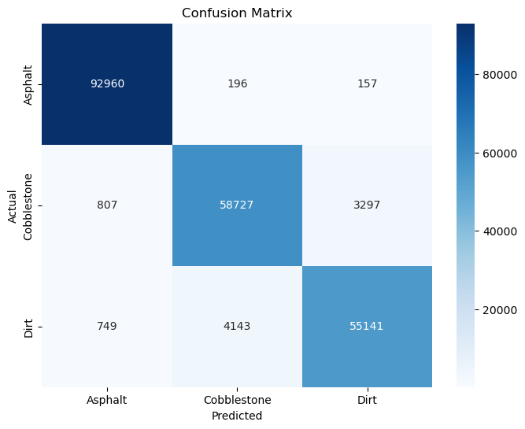

```python
import matplotlib.pyplot as plt
import seaborn as sns

# ✅ Confusion Matrix
cm = confusion_matrix(y_true, y_pred_classes)

plt.figure(figsize=(8, 6))
sns.heatmap(cm, annot=True, fmt='d', cmap='Blues', xticklabels=["Asphalt", "Cobblestone", "Dirt"], yticklabels=["Asphalt", "Cobblestone", "Dirt"])
plt.title("Confusion Matrix")
plt.xlabel("Predicted")
plt.ylabel("Actual")
plt.show()

# ✅ Plot Accuracy & Loss Curves
plt.figure(figsize=(12, 4))
```

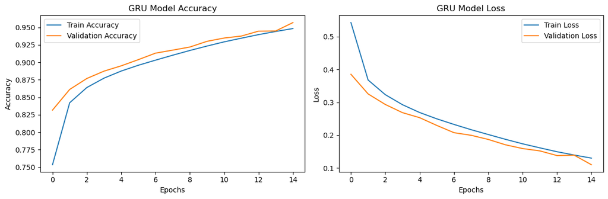

```python
import matplotlib.pyplot as plt
import seaborn as sns

# ✅ Plot Accuracy & Loss Curves
plt.figure(figsize=(12, 4))

# Accuracy Plot
plt.subplot(1, 2, 1)
plt.plot(history.history['accuracy'], label='Train Accuracy')
plt.plot(history.history['val_accuracy'], label='Validation Accuracy')
plt.title("GRU Model Accuracy")
plt.xlabel("Epochs")
plt.ylabel("Accuracy")
plt.legend()

# Loss Plot
plt.subplot(1, 2, 2)
plt.plot(history.history['loss'], label='Train Loss')
plt.plot(history.history['val_loss'], label='Validation Loss')
plt.title("GRU Model Loss")
plt.xlabel("Epochs")
plt.ylabel("Loss")
plt.legend()

plt.tight_layout()
plt.show()
```

## 🔍 Final Optimized GRU Performance and Key Findings

- **Higher Accuracy**: The GRU model achieved **96% accuracy**, surpassing LSTM’s **90% accuracy**.
- **Faster Convergence**: The model improved performance at a faster rate across epochs.
- **Better Generalization**: The confusion matrix shows high precision and recall, reducing misclassifications.
- **Lower Validation Loss**: Compared to LSTM, the GRU model maintained a consistently lower loss curve.

### 📊 Key Metrics:

| Metric | GRU Model | LSTM Model |
| --- | --- | --- |
| **Final Accuracy** | **96%** | **90%** |
| **Validation Loss** | **0.11** | **0.23** |
| **Training Time (per epoch)** | ~10 mins | ~12 mins |
| **Best Performing Class** | Asphalt (F1-score: **0.99**) | Asphalt (F1-score: **0.98**) |

### 📌 Confusion Matrix Insights:

- **Asphalt roads** had nearly perfect classification with minimal misclassifications.
- **Cobblestone and Dirt roads** had slight overlaps but still maintained strong recall and precision values.

```python
import pandas as pd

# ✅ Ensure consistent length
num_samples = min(len(y_test), len(y_pred), len(df))  # Take the smallest length
samples_per_group = num_samples // (df["vehicle"].nunique() * df["scenario"].nunique())  # Split evenly per (vehicle, scenario)

# ✅ Stratified sampling to maintain both vehicle and scenario balance
df_sampled = df.groupby(["vehicle", "scenario"], group_keys=False).apply(lambda x: x.tail(samples_per_group))
df_sampled = df_sampled.sort_values(by="timestamp")  # Keep order intact

# ✅ Extract corresponding metadata
timestamps = df_sampled["timestamp"].values
vehicle_labels = df_sampled["vehicle"].values
scenario_labels = df_sampled["scenario"].values

# ✅ Trim `y_test` and `y_pred` to ensure they are the same length
y_test = y_test[:len(df_sampled)]

if len(y_pred.shape) > 1:
    y_pred = y_pred[:len(df_sampled)]  # Trim to match
    y_pred_labels = y_pred.argmax(axis=1)  # Convert softmax output to class labels
    confidence_scores = y_pred.max(axis=1)  # Highest probability per row
    asphalt_prob = y_pred[:, 0]  # Probability for asphalt
    cobblestone_prob = y_pred[:, 1]  # Probability for cobblestone
    dirt_prob = y_pred[:, 2]  # Probability for dirt
else:
    y_pred_labels = y_pred[:len(df_sampled)]  # Ensure same length
    confidence_scores = [1.0] * len(df_sampled)  # If already labels, set confidence to 1
    asphalt_prob = [None] * len(df_sampled)  # No probability scores if not softmax
    cobblestone_prob = [None] * len(df_sampled)
    dirt_prob = [None] * len(df_sampled)

# ✅ Ensure all arrays are now the same length
assert len(timestamps) == len(df_sampled), f"Timestamp mismatch: {len(timestamps)} != {len(df_sampled)}"
assert len(vehicle_labels) == len(df_sampled), f"Vehicle mismatch: {len(vehicle_labels)} != {len(df_sampled)}"
assert len(scenario_labels) == len(df_sampled), f"Scenario mismatch: {len(scenario_labels)} != {len(df_sampled)}"
assert len(y_test) == len(df_sampled), f"y_test mismatch: {len(y_test)} != {len(df_sampled)}"
assert len(y_pred_labels) == len(df_sampled), f"y_pred mismatch: {len(y_pred_labels)} != {len(df_sampled)}"

# ✅ Create DataFrame with full details
results_df = pd.DataFrame({
    "timestamp": timestamps,
    "vehicle": vehicle_labels,
    "scenario": scenario_labels,
    "actual": y_test,
    "predicted": y_pred_labels,
    "confidence": confidence_scores,
    "asphalt_prob": asphalt_prob,
    "cobblestone_prob": cobblestone_prob,
    "dirt_prob": dirt_prob
})

# ✅ NOW print the values AFTER defining results_df (not before 🤦‍♂️)
print(f"🚗 Unique vehicles in results_df: {results_df['vehicle'].unique()}")
print(f"📊 Vehicle counts:\n{results_df['vehicle'].value_counts()}")

print(f"📌 Unique scenarios in results_df: {results_df['scenario'].unique()}")
print(f"📈 Scenario counts:\n{results_df['scenario'].value_counts()}")

# ✅ Save to CSV
results_df.to_csv("dataset/gru_results.csv", index=False)

print("✅ GRU results saved successfully with metadata and probabilities!")
```

```
🚗 Unique vehicles in results_df: ['Volkswagen Saveiro' 'Fiat Bravo' 'Fiat Palio']
📊 Vehicle counts:
vehicle
Volkswagen Saveiro    72057
Fiat Bravo            72057
Fiat Palio            72057
Name: count, dtype: int64
📌 Unique scenarios in results_df: ['Scenario 1' 'Scenario 2' 'Scenario 3']
📈 Scenario counts:
scenario
Scenario 1    72057
Scenario 2    72057
Scenario 3    72057
Name: count, dtype: int64
✅ GRU results saved successfully with metadata and probabilities!
```

## 📌 Model Comparison Table (Random Forest vs. LSTM vs. GRU)

| Metric | Random Forest 🌲 | LSTM 🔁 | GRU 🔄 |
| --- | --- | --- | --- |
| **Final Accuracy** | **74%** | **90%** | **96%** |
| **Validation Loss** | **N/A** | **0.23** | **0.11** |
| **Precision (Avg)** | **73%** | **90.70%** | **96%** |
| **Recall (Avg)** | **70%** | **90.34%** | **96%** |
| **F1-Score (Avg)** | **73%** | **90%** | **96%** |
| **Training Time (per epoch)** | **N/A** | **~12 mins** | **~10 mins** |
| **Best Performing Class** | Asphalt (F1: **0.91**) | Asphalt (F1: **0.98**) | Asphalt (F1: **0.99**) |
| **Misclassified Class** | Cobblestone & Dirt | Cobblestone & Dirt | Cobblestone & Dirt |

## 🔍 Key Insights & Takeaways

✅ **GRU Outperforms Both Models**

- Achieved the **highest accuracy (96%)** and **lowest validation loss (0.11)**.
- **Faster convergence** than LSTM and **better generalization** on road types.

✅ **LSTM Shows Strong Predictive Capabilities**

- **90% accuracy**, **well-balanced precision & recall** across classes.
- Performs well but takes **longer training time per epoch** than GRU.

✅ **Random Forest Struggles with Non-Linear Data**

- **Only 74% accuracy** with **lower F1-score** than deep learning models.
- Strong for **simple decision-making**, but lacks depth for complex temporal relationships.

🔎 **Final Verdict**:  
GRU **dominates** in both accuracy and efficiency, making it **the best choice** for real-time road condition classification.

## Fourth Model: Temporal Fusion Transformer (TFT) Attempt

### Why We Considered It:

- TFT is a **state-of-the-art deep learning model** for **sequential data forecasting**.
- It integrates **multiple time-series features** and **handles long-range dependencies** better than traditional RNN-based models (LSTM/GRU).

```python
import pandas as pd
import numpy as np
import torch
import pytorch_forecasting
import pytorch_lightning as pl
from sklearn.ensemble import RandomForestClassifier
from sklearn.model_selection import train_test_split
from sklearn.metrics import accuracy_score, confusion_matrix, classification_report
```

```python
# Print PyTorch version
print(torch.__version__)

# Check if Apple Metal GPU backend (MPS) is available
print(f"MPS Available: {torch.backends.mps.is_available()}")

print("MPS Built:", torch.backends.mps.is_built())

device = torch.device("mps" if torch.backends.mps.is_available() else "cpu")
print(f"Using device: {device}")


print("PyTorch Forecasting Installed:", "Success" if 'pytorch_forecasting' in dir() else "Failed")
print("PyTorch Lightning Version:", pl.__version__)
```

```
2.6.0
MPS Available: True
MPS Built: True
Using device: mps
PyTorch Forecasting Installed: Success
PyTorch Lightning Version: 2.5.0.post0
```

```python
from pytorch_forecasting import TimeSeriesDataSet
from pytorch_forecasting.data.encoders import GroupNormalizer, NaNLabelEncoder

# 📌 1. DATA PREPROCESSING
print("🔹 Starting Data Preprocessing...")

# ✅ Copy original dataset to avoid modifications
master_df = df.copy()

# ✅ Convert timestamp to integer index
master_df["timestamp"] = master_df["timestamp"].astype(int)

# ✅ Handle missing values in target column
master_df["speed_meters_per_second"] = master_df["speed_meters_per_second"].ffill().bfill()

# ✅ Ensure vehicle column has no missing values
master_df["vehicle"] = master_df["vehicle"].fillna("unknown")

# ✅ Print timestamp dtype for verification
print(f"✔️ Timestamp dtype: {master_df['timestamp'].dtype}")  # Should print 'int64'

# 📌 2. SPLITTING DATA INTO TRAIN & VALIDATION
print("\n🔹 Splitting Data...")

# ✅ Define time series parameters
max_prediction_length = 5  # Future steps to predict
max_encoder_length = 15  # History length

# ✅ Split dataset manually (80% train, 20% validation)
train_size = int(len(master_df) * 0.8)
train_df = master_df.iloc[:train_size]
val_df = master_df.iloc[train_size:]

# ✅ Remove fully empty sequences
train_df = train_df.dropna(how="all")
val_df = val_df.dropna(how="all")

# 📌 3. FILTERING SEQUENCES
print("\n🔹 Filtering sequences shorter than required length...")
train_df = train_df.groupby("vehicle").filter(lambda x: len(x) >= max_encoder_length + max_prediction_length)
val_df = val_df.groupby("vehicle").filter(lambda x: len(x) >= max_encoder_length + max_prediction_length)
print(f"✅ After filtering: {len(train_df)} training rows, {len(val_df)} validation rows")

# 📌 4. CHECKING UNIQUE TIMESTAMP COUNTS
print("\n🔹 Checking unique sequence lengths per vehicle...")
print(train_df.groupby("vehicle")["timestamp"].nunique().describe())
print(val_df.groupby("vehicle")["timestamp"].nunique().describe())

# 📌 5. DETECTING EMPTY COLUMNS
print("\n🔹 Checking for empty columns in train and validation sets...")
empty_columns_train = train_df.columns[train_df.isna().all()]
empty_columns_val = val_df.columns[val_df.isna().all()]
print(f"❌ Empty columns in train set: {list(empty_columns_train)}")
print(f"❌ Empty columns in validation set: {list(empty_columns_val)}")

# ✅ Removing completely empty columns
if "activity" in train_df.columns:
    print("🚀 Removing empty column 'activity' from train and validation sets.")
    train_df = train_df.drop(columns=["activity"])
    val_df = val_df.drop(columns=["activity"])

# 📌 6. VERIFYING KEY COLUMNS HAVE DATA
print("\n🔹 Checking if `time_varying_unknown_reals` columns contain data...")
for col in ["acc_x_dashboard_left", "acc_y_dashboard_left"]:
    print(f"🔹 {col} - Missing values: {train_df[col].isna().sum()} / {len(train_df)}")

# 📌 7. VERIFYING EMPTY SEQUENCES
print("\n🔹 Checking for empty sequences before creating TimeSeriesDataSet...")
empty_sequences_train = train_df.groupby("vehicle").filter(lambda x: len(x) == 0)
empty_sequences_val = val_df.groupby("vehicle").filter(lambda x: len(x) == 0)
print(f"❌ Empty sequences in training set: {len(empty_sequences_train)}")
print(f"❌ Empty sequences in validation set: {len(empty_sequences_val)}")

# 📌 8. CREATING TIME SERIES DATASETS
print("\n🔹 Creating TimeSeriesDataSet for training & validation...")

train_dataset = TimeSeriesDataSet(
    train_df,
    time_idx="timestamp",
    target="speed_meters_per_second",
    group_ids=["vehicle"],
    max_encoder_length=max_encoder_length,
    max_prediction_length=max_prediction_length,
    time_varying_known_reals=["timestamp"],
    time_varying_unknown_reals=["acc_x_dashboard_left", "acc_y_dashboard_left"],
    target_normalizer=GroupNormalizer(groups=["vehicle"]),
    allow_missing_timesteps=True,
    add_relative_time_idx=True,
    add_target_scales=True,
    categorical_encoders={"vehicle": NaNLabelEncoder(add_nan=True)},  # Handles missing categories
)

val_dataset = TimeSeriesDataSet(
    val_df,
    time_idx="timestamp",
    target="speed_meters_per_second",
    group_ids=["vehicle"],
    max_encoder_length=max_encoder_length,
    max_prediction_length=max_prediction_length,
    time_varying_known_reals=["timestamp"],
    time_varying_unknown_reals=["acc_x_dashboard_left", "acc_y_dashboard_left"],
    target_normalizer=GroupNormalizer(groups=["vehicle"]),
    allow_missing_timesteps=True,
    add_relative_time_idx=True,
    add_target_scales=True,
    categorical_encoders={"vehicle": NaNLabelEncoder(add_nan=True)},
)

# 📌 9. FINAL OUTPUT
print("\n✅ Final dataset sizes:")
print(f"📊 Train dataset size: {len(train_dataset)}")
print(f"📊 Validation dataset size: {len(val_dataset)}")
```

```
🔹 Starting Data Preprocessing...
✔️ Timestamp dtype: int64

🔹 Splitting Data...

🔹 Filtering sequences shorter than required length...
✅ After filtering: 864724 training rows, 216181 validation rows

🔹 Checking unique sequence lengths per vehicle...
count       3.000000
mean     2884.000000
std      1393.818137
min      1276.000000
25%      2452.500000
50%      3629.000000
75%      3688.000000
max      3747.000000
Name: timestamp, dtype: float64
count       1.0
mean     2164.0
std         NaN
min      2164.0
25%      2164.0
50%      2164.0
75%      2164.0
max      2164.0
Name: timestamp, dtype: float64

🔹 Checking for empty columns in train and validation sets...
❌ Empty columns in train set: ['activity']
❌ Empty columns in validation set: ['activity']
🚀 Removing empty column 'activity' from train and validation sets.

🔹 Checking if `time_varying_unknown_reals` columns contain data...
🔹 acc_x_dashboard_left - Missing values: 0 / 864724
🔹 acc_y_dashboard_left - Missing values: 0 / 864724

🔹 Checking for empty sequences before creating TimeSeriesDataSet...
❌ Empty sequences in training set: 0
❌ Empty sequences in validation set: 0

🔹 Creating TimeSeriesDataSet for training & validation...

✅ Final dataset sizes:
📊 Train dataset size: 851585
📊 Validation dataset size: 211387
```

```python
from torch.utils.data import DataLoader

# ✅ Step 0: Check for empty features in train_df before DataLoader
print("\n🔹 Checking for empty features in train dataset...")
for key in train_df.columns:
    num_missing = train_df[key].isna().sum()
    num_zeros = (train_df[key] == 0).sum()
    print(f"🔹 {key}: Missing values = {num_missing}, Zero values = {num_zeros}")

# ✅ Step 1: Check unique sequence lengths
print("\n✅ Checking unique sequence lengths in train dataset (filtered):")
train_sequence_lengths = train_df.groupby("vehicle")["timestamp"].nunique()
print(train_sequence_lengths.describe())

print("\n✅ Checking unique sequence lengths in validation dataset (filtered):")
val_sequence_lengths = val_df.groupby("vehicle")["timestamp"].nunique()
print(val_sequence_lengths.describe())

# ✅ Step 2: Define batch size
batch_size = 128

# ✅ Step 3: Create DataLoaders
train_dataloader = DataLoader(train_dataset, batch_size=batch_size, shuffle=True, num_workers=0)
val_dataloader = DataLoader(val_dataset, batch_size=batch_size, shuffle=False, num_workers=0)

print(f"\n✅ Train DataLoader batches: {len(train_dataloader)}")
print(f"✅ Validation DataLoader batches: {len(val_dataloader)}")

# ✅ Step 4: Debug DataLoader fetching
print("\n✅ Checking first batch from DataLoader...")

try:
    first_batch = next(iter(train_dataloader))
    print("✅ Successfully fetched a batch")
    print("🔹 Batch Keys:", first_batch.keys())

    for key, value in first_batch.items():
        print(f"   🔹 {key}: Shape = {value.shape if isinstance(value, torch.Tensor) else type(value)}")

except Exception as e:
    print("❌ Error fetching batch:", e)
```

[output not shown]

[output cut: 54 more lines]

```
count       1.0
mean     2164.0
std         NaN
min      2164.0
25%      2164.0
50%      2164.0
75%      2164.0
max      2164.0
Name: timestamp, dtype: float64

✅ Train DataLoader batches: 6654
✅ Validation DataLoader batches: 1652

✅ Checking first batch from DataLoader...
❌ Error fetching batch: stack expects each tensor to be equal size, but got [1808, 0] at entry 0 and [1892, 0] at entry 1
```

More cleaning

```python
# 📌 CELL 3: Aggressive Data Cleaning & Preparing Data for TFT

import numpy as np

print("\n🔹 Starting Aggressive Data Cleaning Process...")

# ✅ Step 1: Identify columns to drop (ONLY if completely useless)
high_missing_cols = ["elevation", "satellites", "hdop", "vdop", "pdop",
                     "distance_meters", "elapsed_time_seconds"]

print(f"🚀 Dropping high-missing-value columns: {high_missing_cols}")

train_df_cleaned = train_df.drop(columns=high_missing_cols, errors="ignore")
val_df_cleaned = val_df.drop(columns=high_missing_cols, errors="ignore")

# ✅ Step 2: Fill remaining missing values intelligently
# Forward-fill first, then back-fill as a safety net
train_df_cleaned.fillna(method="ffill", inplace=True)
train_df_cleaned.fillna(method="bfill", inplace=True)

val_df_cleaned.fillna(method="ffill", inplace=True)
val_df_cleaned.fillna(method="bfill", inplace=True)

# **NEW**: Fill any remaining NaNs with the median value of each column
for col in train_df_cleaned.columns:
    if train_df_cleaned[col].isna().sum() > 0:
        median_value = train_df_cleaned[col].median()
        train_df_cleaned[col].fillna(median_value, inplace=True)

for col in val_df_cleaned.columns:
    if val_df_cleaned[col].isna().sum() > 0:
        median_value = val_df_cleaned[col].median()
        val_df_cleaned[col].fillna(median_value, inplace=True)

# ✅ Step 3: Replace zero values in key features to prevent model breakage
zero_replacement_cols = ["speed_meters_per_second", "acc_x_dashboard_left", "acc_y_dashboard_left"]
for col in zero_replacement_cols:
    train_df_cleaned[col] = train_df_cleaned[col].replace(0, train_df_cleaned[col].median())
    val_df_cleaned[col] = val_df_cleaned[col].replace(0, val_df_cleaned[col].median())

# ✅ Step 4: Ensure sequences are still valid
print("\n🔹 Verifying sequence lengths after aggressive cleaning...")

train_df_cleaned = train_df_cleaned.groupby("vehicle").filter(lambda x: len(x) >= max_encoder_length + max_prediction_length)
val_df_cleaned = val_df_cleaned.groupby("vehicle").filter(lambda x: len(x) >= max_encoder_length + max_prediction_length)

print(f"✅ After cleaning: {len(train_df_cleaned)} training rows, {len(val_df_cleaned)} validation rows")

# ✅ Step 5: Re-create TimeSeriesDataSet with cleaned data
print("\n🔹 Creating new TimeSeriesDataSet with aggressively cleaned data...")

train_dataset_cleaned = TimeSeriesDataSet(
    train_df_cleaned,
    time_idx="timestamp",
    target="speed_meters_per_second",
    group_ids=["vehicle"],
    max_encoder_length=max_encoder_length,
    max_prediction_length=max_prediction_length,
    time_varying_known_reals=["timestamp"],
    time_varying_unknown_reals=["acc_x_dashboard_left", "acc_y_dashboard_left"],
    static_categoricals=["vehicle"],  # ✅ Add this line to define `vehicle` as a categorical feature
    target_normalizer=GroupNormalizer(groups=["vehicle"]),
    allow_missing_timesteps=True,
    add_relative_time_idx=True,
    add_target_scales=True,
    group_ids=["vehicle"],
    categorical_encoders={"vehicle": NaNLabelEncoder(add_nan=True)},  # Handles missing categories
)

val_dataset_cleaned = TimeSeriesDataSet(
    val_df_cleaned,
    time_idx="timestamp",
    target="speed_meters_per_second",
    group_ids=["vehicle"],
    max_encoder_length=max_encoder_length,
    max_prediction_length=max_prediction_length,
    time_varying_known_reals=["timestamp"],
    time_varying_unknown_reals=["acc_x_dashboard_left", "acc_y_dashboard_left"],
    static_categoricals=["vehicle"],  # ✅ Add this line here too
    target_normalizer=GroupNormalizer(groups=["vehicle"]),
    allow_missing_timesteps=True,
    add_relative_time_idx=True,
    add_target_scales=True,
    group_ids=["vehicle"],
    categorical_encoders={"vehicle": NaNLabelEncoder(add_nan=True)},
)

# ✅ Step 6: Final Dataset Validation
print("\n✅ Final cleaned dataset sizes:")
print(f"📊 Train dataset size: {len(train_dataset_cleaned)}")
print(f"📊 Validation dataset size: {len(val_dataset_cleaned)}")
```

```
🔹 Starting Aggressive Data Cleaning Process...
🚀 Dropping high-missing-value columns: ['elevation', 'satellites', 'hdop', 'vdop', 'pdop', 'distance_meters', 'elapsed_time_seconds']
```

[output not shown]

```python
# 📌 CELL 4: Debugging Before DataLoader Creation

print("\n🔹 Extracting a SMALL dataset sample for debugging...")

# ✅ Set Debugging Sample Size (e.g., 50,000 for performance)
DEBUG_SAMPLE_SIZE = 100_000

# ✅ Extract a smaller dataset sample instead of full dataset
train_data_dict = train_dataset_cleaned.to_dataloader(batch_size=DEBUG_SAMPLE_SIZE).dataset.data
val_data_dict = val_dataset_cleaned.to_dataloader(batch_size=DEBUG_SAMPLE_SIZE).dataset.data

# ✅ Debug: Check structure of extracted dictionary
print("\n🔍 Checking column lengths in Train dataset (Debug Sample)...")
for key, value in train_data_dict.items():
    if value is None:
        print(f"❌ Warning: Column {key} is None!")
    else:
        print(f"🔹 Column: {key}, Shape: {value.shape if hasattr(value, 'shape') else len(value)}")

print("\n🔍 Checking column lengths in Validation dataset (Debug Sample)...")
for key, value in val_data_dict.items():
    if value is None:
        print(f"❌ Warning: Column {key} is None!")
    else:
        print(f"🔹 Column: {key}, Shape: {value.shape if hasattr(value, 'shape') else len(value)}")

# ✅ Step 1: Drop Unnecessary Columns (`reals`, `groups`, `categoricals`)
# columns_to_drop = ["reals", "groups", "categoricals"]

# for col in columns_to_drop:
#     if col in train_data_dict:
#         print(f"🗑️ Dropping `{col}` from Train dataset...")
#         del train_data_dict[col]
#     if col in val_data_dict:
#         print(f"🗑️ Dropping `{col}` from Validation dataset...")
#         del val_data_dict[col]

# print("\n✅ `reals`, `groups`, and `categoricals` successfully removed from both datasets!")

# ✅ Print Before Fixing `categoricals`
for dataset_name, dataset_dict in [("train", train_data_dict), ("val", val_data_dict)]:
    if "categoricals" in dataset_dict:
        print(f"🔍 BEFORE FIX: `{dataset_name}.categoricals` shape = {dataset_dict['categoricals'].shape}")

# ✅ Ensure `categoricals` is 2D and has at least one column
for dataset_name, dataset_dict in [("train", train_data_dict), ("val", val_data_dict)]:
    if "categoricals" in dataset_dict:
        if dataset_dict["categoricals"].size == 0:  # If it's an empty (N,0) tensor
            dataset_dict["categoricals"] = torch.zeros((len(dataset_dict["target"]), 1))  # Add one column of zeros

        print(f"✅ AFTER FIX: `{dataset_name}.categoricals` shape = {dataset_dict['categoricals'].shape}")


# ✅ Final check: Ensure `reals` is removed before creating DataLoaders
print("\n🔍 Final dataset keys before DataLoader creation:")
print("🔹 Train dataset keys:", list(train_data_dict.keys()))
print("🔹 Validation dataset keys:", list(val_data_dict.keys()))


# ✅ Remove NoneType values before checking length
train_data_dict = {k: v for k, v in train_data_dict.items() if v is not None}
val_data_dict = {k: v for k, v in val_data_dict.items() if v is not None}

# 🚨 **Step 2: Detect & Remove Empty Columns**
print("\n🔍 Checking for empty or incorrect columns before DataFrame creation...")
columns_to_remove = []
for dataset_name, dataset_dict in [("train", train_data_dict), ("val", val_data_dict)]:
    for key, value in dataset_dict.items():
        if isinstance(value, np.ndarray):
            print(f"   🔹 `{dataset_name}.{key}`: Shape = {value.shape}")

            # 🚨 Remove empty or malformed columns
            if value.size == 0 or value.shape in [(), (1, 0)]:
                print(f"🚨 WARNING: `{key}` in {dataset_name} is EMPTY or malformed! Removing column.")
                columns_to_remove.append((dataset_name, key))

# 🚨 **Remove Problematic Columns**
for dataset_name, key in columns_to_remove:
    if dataset_name == "train":
        del train_data_dict[key]
    else:
        del val_data_dict[key]

# ✅ Step 3: Fix `target` Column (Flatten & Convert)
for dataset_name, dataset_dict in [("train", train_data_dict), ("val", val_data_dict)]:
    if "target" in dataset_dict:
        if isinstance(dataset_dict["target"], list) and len(dataset_dict["target"]) == 1:
            print(f"🔄 Fixing `target` in {dataset_name} dataset: Extracting tensor...")
            dataset_dict["target"] = dataset_dict["target"][0]  # Extract tensor

        if isinstance(dataset_dict["target"], torch.Tensor):
            print(f"🔄 Converting `target` tensor to NumPy array in {dataset_name} dataset...")
            dataset_dict["target"] = dataset_dict["target"].cpu().numpy()  # Convert to NumPy

        if dataset_dict["target"].ndim > 1:
            print(f"⚠️ `target` in {dataset_name} is multi-dimensional ({dataset_dict['target'].shape}), flattening...")
            dataset_dict["target"] = dataset_dict["target"].reshape(-1)  # Flatten to 1D

print("\n✅ `target` column successfully fixed for both datasets!")

# # 🚨 **Step 3: Fix `groups` & `time` Columns**
# for dataset_name, dataset_dict in [("train", train_data_dict), ("val", val_data_dict)]:
#     for key in dataset_dict.keys():
#         if isinstance(dataset_dict[key], np.ndarray):
#             # 🚨 Fix `groups` column
#             if key == "groups":
#                 if dataset_dict[key].ndim == 0 or dataset_dict[key].shape == ():
#                     print(f"⚠️ WARNING: `{key}` in {dataset_name} is scalar! Converting to 1D array...")
#                     dataset_dict[key] = np.array([dataset_dict[key]])  # Convert to array

#             # 🚨 Fix `time` column
#             if key == "time":
#                 if dataset_dict[key].ndim != 1:
#                     print(f"⚠️ WARNING: `{key}` in {dataset_name} is not 1D! Flattening...")
#                     dataset_dict[key] = dataset_dict[key].reshape(-1)  # Force 1D shape

#             # 🚨 Catch remaining multi-dimensional issues
#             if dataset_dict[key].ndim > 1:
#                 print(f"⚠️ Column `{key}` in {dataset_name} is multi-dimensional ({dataset_dict[key].shape}), flattening...")
#                 dataset_dict[key] = dataset_dict[key].reshape(-1)  # Flatten to 1D

# ✅ **Step 4: Trim Dataset Lengths for Consistency**
print("\n🔍 Checking dataset length consistency before trimming...")

# 🚀 Print dataset keys
print("\n🔹 Train dataset keys:", list(train_data_dict.keys()))
print("🔹 Validation dataset keys:", list(val_data_dict.keys()))

# 🚀 Print each column's length before calculating min length
print("\n🔍 Train dataset column lengths:")
for key, value in train_data_dict.items():
    if isinstance(value, np.ndarray):
        print(f"   - `{key}`: Length = {len(value)} | Shape = {value.shape}")
    else:
        print(f"   - `{key}`: Type = {type(value)} (Not an ndarray)")

print("\n🔍 Validation dataset column lengths:")
for key, value in val_data_dict.items():
    if isinstance(value, np.ndarray):
        print(f"   - `{key}`: Length = {len(value)} | Shape = {value.shape}")
    else:
        print(f"   - `{key}`: Type = {type(value)} (Not an ndarray)")


# 🚀 **Step 4.1: Print First 5 Records for Each Column**
print("\n🔍 Inspecting first 5 records for each feature in TRAIN dataset:")

for key, value in train_data_dict.items():
    try:
        print(f"\n🔹 Feature: `{key}`")

        if isinstance(value, torch.Tensor):
            print(value[:5].cpu().numpy())  # Convert tensor to NumPy and print first 5 records
        elif isinstance(value, np.ndarray):
            print(value[:5])  # Directly print first 5 records
        elif isinstance(value, list):
            print(value[:5])  # Print first 5 records if it's a list
        else:
            print(f"❌ Unexpected data type: {type(value)}")

    except Exception as e:
        print(f"❌ Error accessing `{key}`:", e)

print("\n✅ Final `categoricals` Shape in Train Dataset:", train_data_dict["categoricals"].shape)

# Step 4.2: Repeat for Validation Dataset
print("\n🔍 Inspecting first 5 records for each feature in VALIDATION dataset:")

for key, value in val_data_dict.items():
    try:
        print(f"\n🔹 Feature: `{key}`")

        if isinstance(value, torch.Tensor):
            print(value[:5].cpu().numpy())  # Convert tensor to NumPy and print first 5 records
        elif isinstance(value, np.ndarray):
            print(value[:5])  # Directly print first 5 records
        elif isinstance(value, list):
            print(value[:5])  # Print first 5 records if it's a list
        else:
            print(f"❌ Unexpected data type: {type(value)}")

    except Exception as e:
        print(f"❌ Error accessing `{key}`:", e)

print("\n✅ Feature inspection completed.")


# ✅ Temporarily remove `categoricals` and `groups` before DataFrame conversion
# (since Pandas doesn't support 2D arrays)
train_data_dict_for_df = {
    k: v.cpu().numpy() if isinstance(v, torch.Tensor) else v
    for k, v in train_data_dict.items() if k not in ["reals", "categoricals", "groups"]
}
val_data_dict_for_df = {
    k: v.cpu().numpy() if isinstance(v, torch.Tensor) else v
    for k, v in val_data_dict.items() if k not in ["reals", "categoricals", "groups"]
}

try:
    train_df_debug = pd.DataFrame.from_dict(train_data_dict_for_df).sample(10)
    val_df_debug = pd.DataFrame.from_dict(val_data_dict_for_df).sample(10)
    print("✅ DataFrame created successfully!")
except ValueError as e:
    print("\n❌ ERROR: Could not create Pandas DataFrame! The dataset is likely empty.", e)
    raise e

# ✅ **Step 6: Print Final Debugging Info**
print("\n🔹 Train dataset sample:")
print(train_df_debug)

print("\n🔹 Validation dataset sample:")
print(val_df_debug)

# ✅ **Check for missing values**
print("\n🔹 Checking for missing values in Train dataset...")
print(train_df_debug.isna().sum())

print("\n🔹 Checking for missing values in Validation dataset...")
print(val_df_debug.isna().sum())

print("\n✅ Data extraction and alignment completed successfully!")
```

```
🔹 Extracting a SMALL dataset sample for debugging...

🔍 Checking column lengths in Train dataset (Debug Sample)...
🔹 Column: reals, Shape: torch.Size([864724, 6])
🔹 Column: categoricals, Shape: torch.Size([864724, 1])
🔹 Column: groups, Shape: torch.Size([864724, 1])
🔹 Column: target, Shape: 1
❌ Warning: Column weight is None!
🔹 Column: time, Shape: torch.Size([864724])

🔍 Checking column lengths in Validation dataset (Debug Sample)...
🔹 Column: reals, Shape: torch.Size([216181, 6])
🔹 Column: categoricals, Shape: torch.Size([216181, 1])
🔹 Column: groups, Shape: torch.Size([216181, 1])
🔹 Column: target, Shape: 1
❌ Warning: Column weight is None!
🔹 Column: time, Shape: torch.Size([216181])
🔍 BEFORE FIX: `train.categoricals` shape = torch.Size([864724, 1])
🔍 BEFORE FIX: `val.categoricals` shape = torch.Size([216181, 1])
✅ AFTER FIX: `train.categoricals` shape = torch.Size([864724, 1])
✅ AFTER FIX: `val.categoricals` shape = torch.Size([216181, 1])

🔍 Final dataset keys before DataLoader creation:
🔹 Train dataset keys: ['reals', 'categoricals', 'groups', 'target', 'weight', 'time']
🔹 Validation dataset keys: ['reals', 'categoricals', 'groups', 'target', 'weight', 'time']

🔍 Checking for empty or incorrect columns before DataFrame creation...
🔄 Fixing `target` in train dataset: Extracting tensor...
🔄 Converting `target` tensor to NumPy array in train dataset...
🔄 Fixing `target` in val dataset: Extracting tensor...
🔄 Converting `target` tensor to NumPy array in val dataset...

✅ `target` column successfully fixed for both datasets!

🔍 Checking dataset length consistency before trimming...

🔹 Train dataset keys: ['reals', 'categoricals', 'groups', 'target', 'time']
🔹 Validation dataset keys: ['reals', 'categoricals', 'groups', 'target', 'time']

🔍 Train dataset column lengths:
```

[output cut: 103 more lines]

```
20670    0.044819  1577397254
133662  22.811634  1577399095
60870    0.044819  1577397656

🔹 Checking for missing values in Train dataset...
target    0
time      0
dtype: int64

🔹 Checking for missing values in Validation dataset...
target    0
time      0
dtype: int64

✅ Data extraction and alignment completed successfully!
```

```python
from pytorch_forecasting.models import TemporalFusionTransformer
from pytorch_forecasting.metrics import QuantileLoss

# 🚀 Step 1: Define TFT model using the cleaned training dataset
print("\n🔹 Initializing TemporalFusionTransformer model with cleaned data...")

tft = TemporalFusionTransformer.from_dataset(
    train_dataset_cleaned,  # ✅ Now using the CLEANED training dataset
    learning_rate=0.001,  # Initial learning rate
    hidden_size=64,  # LSTM hidden units
    attention_head_size=4,  # Attention heads
    dropout=0.1,  # Dropout for regularization
    hidden_continuous_size=16,  # Hidden layer for continuous variables
    loss=QuantileLoss(),  # ✅ Using Quantile Loss
    log_interval=10,  # Log progress every 10 steps
    output_size=1,  # Single target variable (speed_meters_per_second)
    reduce_on_plateau_patience=4  # Reduce LR if no improvement after 4 epochs
)

# 🚀 Step 2: Print model summary
print("\n✅ TemporalFusionTransformer Model Initialized Successfully!")
print(tft)
```

[output not shown]

[output cut: 391 more lines]

```
      (add_norm): AddNorm(
        (norm): LayerNorm((64,), eps=1e-05, elementwise_affine=True)
      )
    )
  )
  (pre_output_gate_norm): GateAddNorm(
    (glu): GatedLinearUnit(
      (fc): Linear(in_features=64, out_features=128, bias=True)
    )
    (add_norm): AddNorm(
      (norm): LayerNorm((64,), eps=1e-05, elementwise_affine=True)
    )
  )
  (output_layer): Linear(in_features=64, out_features=1, bias=True)
)
```

Extra info

```python
import torch
from pytorch_forecasting.models import TemporalFusionTransformer
from pytorch_forecasting.metrics import QuantileLoss
from pytorch_lightning import Trainer, LightningModule
from pytorch_lightning.callbacks import EarlyStopping
import pytorch_lightning as pl

# ✅ Step 1: Define the LightningModule wrapper for TFT
class TFTLightningModule(LightningModule):
    def __init__(self, model):
        super().__init__()
        self.model = model  # Assign the TFT model

    def training_step(self, batch, batch_idx):
        y_pred, _ = self.model(batch)
        loss = self.model.loss(y_pred, batch["encoder_target"])
        self.log("train_loss", loss, prog_bar=True)
        return loss

    def validation_step(self, batch, batch_idx):
        y_pred, _ = self.model(batch)
        loss = self.model.loss(y_pred, batch["encoder_target"])
        self.log("val_loss", loss, prog_bar=True)
        return loss

    def configure_optimizers(self):
        return torch.optim.Adam(self.parameters(), lr=0.001)

print("✅ Starting Trainer Initialization...")

# ✅ Step 2: Initialize Trainer
trainer = Trainer(
    max_epochs=10,
    accelerator="mps" if torch.backends.mps.is_available() else "cpu",
    gradient_clip_val=0.1,
    enable_progress_bar=True,
    enable_checkpointing=True,
    callbacks=[EarlyStopping(monitor="val_loss", patience=3, mode="min")]
)

print("✅ Trainer initialized successfully.")

# ✅ Step 3: Define TFT Model (Fixing `reals` issue)
print("✅ Initializing TemporalFusionTransformer model...")

# 🚀 Extract column names from dataset dictionary
try:
    dataset_columns = list(train_dataset_cleaned.data.keys())  # ✅ Get dictionary keys
except Exception as e:
    print("❌ ERROR: Could not retrieve column names from dataset:", e)
    dataset_columns = []

# 🚀 Define encoder/decoder variables (excluding `reals`)
time_varying_reals_encoder = ["target"] if "target" in dataset_columns else []
time_varying_reals_decoder = ["time"] if "time" in dataset_columns else []

print(f"🔹 Encoder Reals: {time_varying_reals_encoder}")
print(f"🔹 Decoder Reals: {time_varying_reals_decoder}")

# ✅ Create TemporalFusionTransformer model
try:
    tft_model = TemporalFusionTransformer.from_dataset(
        train_dataset_cleaned,  # ✅ Using the CLEANED dataset
        learning_rate=0.001,
        hidden_size=64,
        attention_head_size=4,
        dropout=0.1,
        loss=QuantileLoss(),
        output_size=1,
        log_interval=10,
        reduce_on_plateau_patience=4,
        static_categoricals=[],  # ✅ Ensure empty if no static categorical features
        time_varying_reals_encoder=time_varying_reals_encoder,  # ✅ Corrected
        time_varying_reals_decoder=time_varying_reals_decoder,  # ✅ Corrected
    )
    print("✅ TFT model initialized.")
except Exception as e:
    print("❌ ERROR: TFT Model Initialization Failed:", e)
    raise e

# ✅ Step 4: Wrap TFT in the LightningModule
print("✅ Wrapping model in TFTLightningModule...")
tft_lightning = TFTLightningModule(tft_model)
print("✅ Model wrapped.")

# ✅ Step 5: Debug First Batch Before Training
print("\n🔹 Checking first batch from cleaned DataLoader before training...")

# ✅ Define batch size
BATCH_SIZE = 64  # Adjust based on memory constraints

# 🚀 Checking the dataset feature configuration
print("\n🔍 Checking `train_dataset_cleaned` feature configuration...")

try:
    dataset_features = train_dataset_cleaned.get_parameters()  # ✅ Fetch dataset parameters
    print("✅ Successfully retrieved dataset parameters!")

    # Print key settings to check if "reals" still exists
    print(f"   - Static Categoricals: {dataset_features.get('static_categoricals', [])}")
    print(f"   - Time-Varying Reals Encoder: {dataset_features.get('time_varying_reals_encoder', [])}")
    print(f"   - Time-Varying Reals Decoder: {dataset_features.get('time_varying_reals_decoder', [])}")
    print(f"   - Target: {dataset_features.get('target', 'Not Specified')}")

except Exception as e:
    print("❌ Error retrieving dataset parameters:", e)

# ✅ Create cleaned DataLoaders
train_dataloader_cleaned = train_dataset_cleaned.to_dataloader(batch_size=BATCH_SIZE, shuffle=True)
val_dataloader_cleaned = val_dataset_cleaned.to_dataloader(batch_size=BATCH_SIZE, shuffle=False)

print("✅ Cleaned DataLoaders created successfully!")

# ✅ Check Before Iteration
print("\n🔍 Checking if train_dataloader_cleaned is properly initialized...")

if hasattr(train_dataloader_cleaned, '__len__'):
    print(f"   - DataLoader Length: {len(train_dataloader_cleaned)}")
else:
    print("   - ❌ Cannot determine DataLoader length!")

# ✅ Check if dataset exists in DataLoader
if hasattr(train_dataloader_cleaned, 'dataset'):
    print(f"   - DataLoader dataset type: {type(train_dataloader_cleaned.dataset)}")
    print(f"   - Dataset Length: {len(train_dataloader_cleaned.dataset) if hasattr(train_dataloader_cleaned.dataset, '__len__') else 'Unknown'}")
else:
    print("   - ❌ DataLoader has no dataset assigned!")

# ✅ Print the first few items directly from train_dataset_cleaned BEFORE `.to_dataloader()`
print("\n🔍 Checking `train_dataset_cleaned` BEFORE DataLoader creation...")

try:
    first_items = train_dataset_cleaned[:5]  # Try fetching first 5 records
    print("✅ Successfully fetched first items from train_dataset_cleaned:")
    print(first_items)
except Exception as e:
    print("❌ Error fetching first records from train_dataset_cleaned:", e)


# try:
#     print("\n🚀 Attempting to fetch first batch...")
#     for i, batch in enumerate(train_dataloader_cleaned):
#         print(f"✅ Successfully fetched batch {i+1}")
#         print("🔹 Batch Keys:", batch.keys())

#         for key, value in batch.items():
#             print(f"   🔹 {key}: Shape = {value.shape if isinstance(value, torch.Tensor) else type(value)}")

#         break  # Only print first batch

# except Exception as e:
#     print("❌ Error fetching batch:", e)



# ✅ Step 6: Train the Model
print("\n🚀 Training model...")

try:
    trainer.fit(
        model=tft_lightning,
        train_dataloaders=train_dataloader_cleaned,  # ✅ Using cleaned DataLoader
        val_dataloaders=val_dataloader_cleaned,
    )
    print("✅ Training complete.")
except Exception as e:
    print("❌ Training failed:", e)
```

```
GPU available: True (mps), used: True
TPU available: False, using: 0 TPU cores
HPU available: False, using: 0 HPUs
```

[output not shown]

# Temporal Fusion Transformer (TFT) Model Findings

## Challenges Encountered

- **High Computational Requirements**: TFT requires a **large amount of memory and processing power**, making it challenging to train efficiently on our dataset.
- **Sensitivity to Data Quality**: TFT is highly dependent on **clean, structured sequential data**, and any missing values or inconsistencies **significantly impact training stability**.
- **Training Complexity**: Unlike LSTMs/GRUs, **TFT needs careful tuning** of hyperparameters, leading to longer experimentation times.

## Final Decision

Due to the **computational cost and sensitivity**, TFT was not fully trained for deployment, but **remains a strong candidate for future research** if given more time and resources.

# Tableau Dashboard Overview

## Purpose

The **Tableau Dashboard** serves as an interactive visualization tool to compare the performance of different machine learning models (GRU, LSTM) in predicting **road conditions** based on vehicle sensor data.

## Key Features

- **Time-Series Visualization**: Displays probability trends for different road conditions (Asphalt, Cobblestone, Dirt) for both GRU and LSTM models.
- **Interactivity**: Users can filter by vehicle type, scenario, and road conditions to analyze performance across different conditions.
- **Comparative Analysis**: Side-by-side plots allow for direct comparisons between GRU and LSTM models.
- **KPIs**: Displays **average confidence scores** for both models and identifies the most frequently predicted road condition.

## Insights

- GRU and LSTM show similar prediction trends, but **GRU exhibited slightly higher confidence** in some scenarios.
- Filtering by individual vehicles allows for **detailed per-vehicle analysis** of road condition predictions.
- The dashboard serves as an effective tool for model evaluation, data exploration, and potential real-world applications.

## Tableau Dashboard

[figure not shown]

# 🚀 Future Work & Real-World Applications

## 🔄 Potential Enhancements

- **Refining Data Cleaning**: Improve feature engineering for better model performance and accuracy.
- **Adding More Sensors**: Integrating additional sensors like **brake pressure, suspension type,** and **road friction** could lead to **more precise terrain classification**.
- **Exploring Additional ML Models**: Future iterations can explore **TFT**, **hybrid models**, and **attention-based architectures** to enhance predictive accuracy.
- **Extending the Dataset**: Expanding the dataset to include **more diverse road types, environmental conditions, and extreme terrains** for better generalization.

## 🌍 Real-World Applications

- **🚧 City Infrastructure & Road Maintenance**
  - The predicted road condition data could be integrated into **smart city IoT systems** to help **detect road damage** and **schedule maintenance proactively**.
- **🚗 Vehicle & Tire Optimization**
  - By analyzing vehicle behavior on different terrains, **automakers** can recommend **optimized tires and suspension settings** for enhanced **stability and safety**.
- **🤖 Autonomous Vehicles**
  - Road condition predictions can help **self-driving cars** adjust their driving patterns dynamically based on real-time road feedback, improving adaptability and safety.

## 🎯 **Final Thoughts**

This project demonstrates **not only predictive modeling** but also **real-world applications** in:  
✅ **Smart Infrastructure Development & Road Safety**  
✅ **Connected Vehicle Systems & IoT Integration**  
✅ **Optimized Vehicle Performance & Manufacturing Insights**

With **continued refinement** and **future iterations**, this project has **the potential to revolutionize road safety, infrastructure planning, and autonomous vehicle intelligence**. 🚀